# Project

Hakan Ekiz - IE48B - Fall2021

5 Ocak 2022

## Introduction

In this project, we will try to estimate the difference in trading data in the Turkish electricity market, that is, the imbalance values on a daily basis.In doing so, we will use two different datasets: Bulk-imbalance and Weather files. After developing the model, we will try to predict the hourly imbalance values for the next day’s 12 hours using the daily data. Actually, what we need to do is to find system direction. If the bulk imbalance value is less than -50, system direction is negative;if between -50 and +50, it will be neutral; If it is more than +50, it will be positive.

In our project, as a step, 1) To adapt and combine 2 different datasets for modelling 2) Creating a simple time series model 3) Develop the model (with EBLR) 4) get the results next day.

```r
require(data.table)
require(ggplot2)
require(repr)
require(rpart)
require(rattle)
require(TSrepr)
require(TSdist)
require(dtw)
require(zoo)
require(genlasso)
require(e1071)
require(lubridate)
require(forecast)
require(dplyr)
```

## Data

```r
options(repr.plot.width=15, repr.plot.height=8)

current_folder=getwd()
```

We have 2 different datasets. Bulk_imbalance and weather, first we should import and examni them.

```r
dat=fread('bulk_imbalance2.csv')
weat=fread('2022-01-18_weather.csv')
head(dat)
```

```
##          date hour       net upRegulationZeroCoded upRegulationOneCoded
## 1: 2019-01-01    0 -1934.795                     0                    0
## 2: 2019-01-01    1  -750.866                     0                    0
## 3: 2019-01-01    2  -982.767                     0                    0
## 4: 2019-01-01    3  -764.620                     0                    0
## 5: 2019-01-01    4 -1233.289                     0                    0
## 6: 2019-01-01    5 -1469.061                     0                    0
##    upRegulationTwoCoded downRegulationZeroCoded downRegulationOneCoded
## 1:                    0                2288.567                      0
## 2:                    0                 808.083                      0
## 3:                    0                1060.750                      0
## 4:                    0                1120.483                      0
## 5:                    0                1874.633                     56
## 6:                    0                2125.000                     56
##    downRegulationTwoCoded upRegulationDelivered downRegulationDelivered
## 1:                      0                     0               -1934.795
## 2:                      0                     0                -750.866
## 3:                      0                     0                -982.767
## 4:                      0                     0                -764.620
## 5:                      0                     0               -1233.289
## 6:                      0                     0               -1469.061
##    system_direction
## 1:         Negative
## 2:         Negative
## 3:         Negative
## 4:         Negative
## 5:         Negative
## 6:         Negative
```

```r
head(weat)
```

```
##          date hour  lat  lon      variable value
## 1: 2018-12-31    0 36.5 32.5 DSWRF_surface     0
## 2: 2018-12-31    1 36.5 32.5 DSWRF_surface     0
## 3: 2018-12-31    2 36.5 32.5 DSWRF_surface     0
## 4: 2018-12-31    3 36.5 32.5 DSWRF_surface     0
## 5: 2018-12-31    4 36.5 32.5 DSWRF_surface     0
## 6: 2018-12-31    5 36.5 32.5 DSWRF_surface     0
```

Because we will not use ZeroCoded and OneCoded valeus we eliminate these values. After that, because we should combine 2 dataet, add datetime (Year,month,day, hour) column into the dataset.

```r
c1 = dat
c1 = c1[,list(date,hour,net,system_direction)]
c1[,datetime:=ymd(date)+dhours(hour)]
c1=c1[order(datetime)]

c2 = c1[,list(datetime,net,system_direction)]
head(c2)
```

```
##               datetime       net system_direction
## 1: 2019-01-01 00:00:00 -1934.795         Negative
## 2: 2019-01-01 01:00:00  -750.866         Negative
## 3: 2019-01-01 02:00:00  -982.767         Negative
## 4: 2019-01-01 03:00:00  -764.620         Negative
## 5: 2019-01-01 04:00:00 -1233.289         Negative
## 6: 2019-01-01 05:00:00 -1469.061         Negative
```

```r
w1 = weat
w1[,datetime:=ymd(date)+dhours(hour)]
w1=w1[order(datetime)]

w1 = w1 %>%
  mutate(loc =
           case_when(lat <= 36.50 ~ "loc1" ,
                     lat==37.00 ~ "loc2" ,
                     lat==38.00 ~ "loc3" ,
                     lat==38.50 ~ "loc4" ,
                     lat==39.75 ~ "loc5" ,
                     lat==40.00 ~ "loc6" ,
                     lat>=41.00 ~ "loc7" )
         )
w1= as.data.table(w1)
w1[,class:=paste(loc,variable)]

w2 = w1[,list(datetime,class,value)]
w2[,class:=as.factor(class)]


head(w2)
```

```
##      datetime              class value
## 1: 2018-12-31 loc1 DSWRF_surface     0
## 2: 2018-12-31 loc2 DSWRF_surface     0
## 3: 2018-12-31 loc3 DSWRF_surface     0
## 4: 2018-12-31 loc4 DSWRF_surface     0
## 5: 2018-12-31 loc5 DSWRF_surface     0
## 6: 2018-12-31 loc6 DSWRF_surface     0
```

```r
trainw2=dcast(w2[!is.na(value)],datetime~class,value.var='value')
names(trainw2) <- gsub(" ", "_", names(trainw2))

head(trainw2)
```

```
##               datetime loc1_DSWRF_surface loc1_RH_2.m.above.ground
## 1: 2018-12-31 00:00:00                  0                 83.30000
## 2: 2018-12-31 01:00:00                  0                 82.00000
## 3: 2018-12-31 02:00:00                  0                 80.70000
## 4: 2018-12-31 03:00:00                  0                 79.40000
## 5: 2018-12-31 04:00:00                  0                 78.83333
## 6: 2018-12-31 05:00:00                  0                 78.26667
##    loc1_TCDC_low.cloud.layer loc1_TMP_2.m.above.ground loc1_wdir_10m
## 1:                         0                 -8.284000      219.0959
## 2:                         1                 -8.104667      217.8237
## 3:                         2                 -7.925333      216.5515
## 4:                         3                 -7.746000      215.2793
## 5:                         5                 -7.995333      216.4846
## 6:                         7                 -8.244667      217.6899
##    loc1_ws_10m loc2_DSWRF_surface loc2_RH_2.m.above.ground
```

[output cut: 90 more lines]

Now we have 2 datasets whic are suitable to be used in models and be arranged with each other.

```r
all = merge(c2,trainw2, by="datetime")
head(all)
```

```
##               datetime       net system_direction loc1_DSWRF_surface
## 1: 2019-01-01 00:00:00 -1934.795         Negative                  0
## 2: 2019-01-01 01:00:00  -750.866         Negative                  0
## 3: 2019-01-01 02:00:00  -982.767         Negative                  0
## 4: 2019-01-01 03:00:00  -764.620         Negative                  0
## 5: 2019-01-01 04:00:00 -1233.289         Negative                  0
## 6: 2019-01-01 05:00:00 -1469.061         Negative                  0
##    loc1_RH_2.m.above.ground loc1_TCDC_low.cloud.layer loc1_TMP_2.m.above.ground
## 1:                 84.20000                   0.00000                    -4.081
## 2:                 84.43333                   3.00000                    -3.707
## 3:                 84.66667                   6.00000                    -3.333
## 4:                 84.90000                   9.00000                    -2.959
## 5:                 87.26667                  29.66667                    -2.591
## 6:                 89.63333                  50.33333                    -2.223
##    loc1_wdir_10m loc1_ws_10m loc2_DSWRF_surface loc2_RH_2.m.above.ground
```

[output cut: 90 more lines]

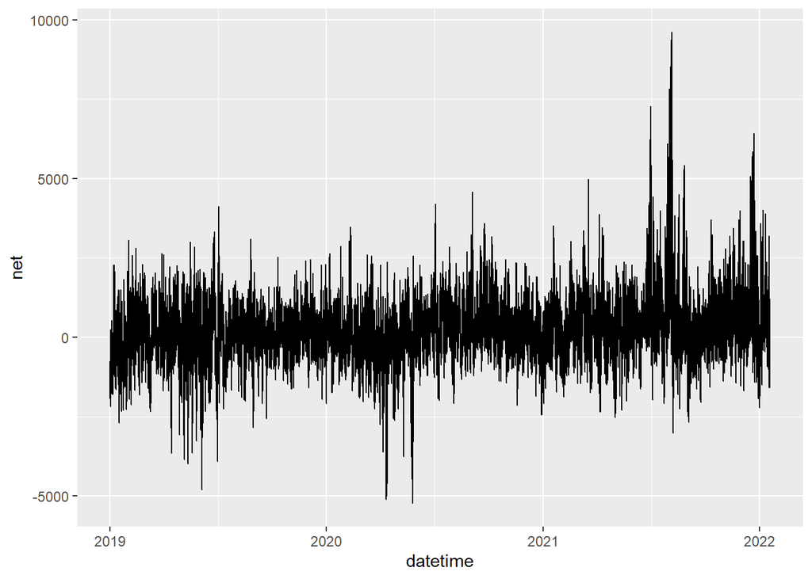

```r
ggplot(all ,aes(x=datetime,y=net)) + geom_line()
```

In the combined dataset, we reveal the values date, weekday, hour, and month using the datetime value. After all these operations, the dataset we get will be like this:

```r
all[,trnd:=1:.N]

all[,w_day:=as.character(wday(datetime,label=T))]
all[,mon:=as.character(month(datetime,label=T))]
all[,hour:=as.factor(hour(datetime))]
all[,Date:=as.Date(datetime)]
head(all)
```

```
##               datetime       net system_direction loc1_DSWRF_surface
## 1: 2019-01-01 00:00:00 -1934.795         Negative                  0
## 2: 2019-01-01 01:00:00  -750.866         Negative                  0
## 3: 2019-01-01 02:00:00  -982.767         Negative                  0
## 4: 2019-01-01 03:00:00  -764.620         Negative                  0
## 5: 2019-01-01 04:00:00 -1233.289         Negative                  0
## 6: 2019-01-01 05:00:00 -1469.061         Negative                  0
##    loc1_RH_2.m.above.ground loc1_TCDC_low.cloud.layer loc1_TMP_2.m.above.ground
## 1:                 84.20000                   0.00000                    -4.081
## 2:                 84.43333                   3.00000                    -3.707
## 3:                 84.66667                   6.00000                    -3.333
## 4:                 84.90000                   9.00000                    -2.959
## 5:                 87.26667                  29.66667                    -2.591
## 6:                 89.63333                  50.33333                    -2.223
##    loc1_wdir_10m loc1_ws_10m loc2_DSWRF_surface loc2_RH_2.m.above.ground
```

[output cut: 90 more lines]

## Models

### Simple Model1

First of all, we wanted to see what kind of result it would give if we put all the variables in the dataset we obtained into a linear model.

```r
lm1=lm(net~trnd+w_day+mon+hour+
         loc1_DSWRF_surface+loc1_RH_2.m.above.ground+loc1_TCDC_low.cloud.layer+loc1_TMP_2.m.above.ground+loc1_wdir_10m+loc1_ws_10m+
         loc2_DSWRF_surface+loc2_RH_2.m.above.ground+loc2_TCDC_low.cloud.layer+loc2_TMP_2.m.above.ground+loc2_wdir_10m+loc1_ws_10m+
         loc3_DSWRF_surface+loc3_RH_2.m.above.ground+loc3_TCDC_low.cloud.layer+loc3_TMP_2.m.above.ground+loc3_wdir_10m+loc1_ws_10m+
         loc4_DSWRF_surface+loc4_RH_2.m.above.ground+loc4_TCDC_low.cloud.layer+loc4_TMP_2.m.above.ground+loc4_wdir_10m+loc1_ws_10m+
         loc5_DSWRF_surface+loc5_RH_2.m.above.ground+loc5_TCDC_low.cloud.layer+loc5_TMP_2.m.above.ground+loc5_wdir_10m+loc1_ws_10m+
         loc6_DSWRF_surface+loc6_RH_2.m.above.ground+loc6_TCDC_low.cloud.layer+loc6_TMP_2.m.above.ground+loc6_wdir_10m+loc1_ws_10m+
         loc7_DSWRF_surface+loc7_RH_2.m.above.ground+loc7_TCDC_low.cloud.layer+loc7_TMP_2.m.above.ground+loc7_wdir_10m+loc1_ws_10m
       ,all)


summary(lm1)
```

```
##
## Call:
## lm(formula = net ~ trnd + w_day + mon + hour + loc1_DSWRF_surface +
##     loc1_RH_2.m.above.ground + loc1_TCDC_low.cloud.layer + loc1_TMP_2.m.above.ground +
##     loc1_wdir_10m + loc1_ws_10m + loc2_DSWRF_surface + loc2_RH_2.m.above.ground +
##     loc2_TCDC_low.cloud.layer + loc2_TMP_2.m.above.ground + loc2_wdir_10m +
##     loc1_ws_10m + loc3_DSWRF_surface + loc3_RH_2.m.above.ground +
##     loc3_TCDC_low.cloud.layer + loc3_TMP_2.m.above.ground + loc3_wdir_10m +
##     loc1_ws_10m + loc4_DSWRF_surface + loc4_RH_2.m.above.ground +
##     loc4_TCDC_low.cloud.layer + loc4_TMP_2.m.above.ground + loc4_wdir_10m +
##     loc1_ws_10m + loc5_DSWRF_surface + loc5_RH_2.m.above.ground +
##     loc5_TCDC_low.cloud.layer + loc5_TMP_2.m.above.ground + loc5_wdir_10m +
##     loc1_ws_10m + loc6_DSWRF_surface + loc6_RH_2.m.above.ground +
##     loc6_TCDC_low.cloud.layer + loc6_TMP_2.m.above.ground + loc6_wdir_10m +
##     loc1_ws_10m + loc7_DSWRF_surface + loc7_RH_2.m.above.ground +
##     loc7_TCDC_low.cloud.layer + loc7_TMP_2.m.above.ground + loc7_wdir_10m +
##     loc1_ws_10m, data = all)
##
## Residuals:
##     Min      1Q  Median      3Q     Max
## -5687.6  -562.9   -21.8   516.8  8412.3
##
## Coefficients:
##                             Estimate Std. Error t value Pr(>|t|)
## (Intercept)                2.932e+02  1.336e+02   2.195 0.028144 *
## trnd                       2.645e-02  8.727e-04  30.308  < 2e-16 ***
## w_dayCum                   1.170e+02  2.236e+01   5.233 1.68e-07 ***
## w_dayÇar                   1.389e+02  2.240e+01   6.203 5.61e-10 ***
## w_dayPaz                  -2.226e+02  2.235e+01  -9.960  < 2e-16 ***
## w_dayPer                   1.846e+02  2.240e+01   8.243  < 2e-16 ***
## w_dayPzt                   1.031e+02  2.236e+01   4.609 4.07e-06 ***
## w_daySal                   1.416e+02  2.240e+01   6.324 2.60e-10 ***
## monAra                     1.568e+02  5.662e+01   2.770 0.005610 **
## monEki                    -1.579e+02  3.781e+01  -4.177 2.97e-05 ***
## monEyl                    -3.136e+02  3.140e+01  -9.986  < 2e-16 ***
## monHaz                    -4.268e+01  3.258e+01  -1.310 0.190265
## monKas                    -3.912e+01  4.726e+01  -0.828 0.407828
## monMar                     7.717e+01  5.706e+01   1.352 0.176308
## monMay                    -1.601e+02  3.880e+01  -4.126 3.70e-05 ***
## monNis                    -9.741e+01  5.107e+01  -1.907 0.056512 .
```

[output cut: 53 more lines]

```
## loc6_RH_2.m.above.ground  -4.846e+00  8.379e-01  -5.783 7.41e-09 ***
## loc6_TCDC_low.cloud.layer  1.669e+00  3.029e-01   5.509 3.65e-08 ***
## loc6_TMP_2.m.above.ground  1.043e-01  5.852e+00   0.018 0.985786
## loc6_wdir_10m             -4.336e-01  7.201e-02  -6.021 1.76e-09 ***
## loc7_DSWRF_surface         2.510e-01  1.109e-01   2.264 0.023555 *
## loc7_RH_2.m.above.ground   5.430e+00  8.521e-01   6.372 1.89e-10 ***
## loc7_TCDC_low.cloud.layer -1.336e-01  2.433e-01  -0.549 0.582873
## loc7_TMP_2.m.above.ground  4.457e+01  4.766e+00   9.352  < 2e-16 ***
## loc7_wdir_10m              6.520e-01  7.810e-02   8.348  < 2e-16 ***
## ---
## Signif. codes:  0 '***' 0.001 '**' 0.01 '*' 0.05 '.' 0.1 ' ' 1
##
## Residual standard error: 972.3 on 26658 degrees of freedom
## Multiple R-squared:  0.1468, Adjusted R-squared:  0.1444
## F-statistic: 59.58 on 77 and 26658 DF,  p-value: < 2.2e-16
```

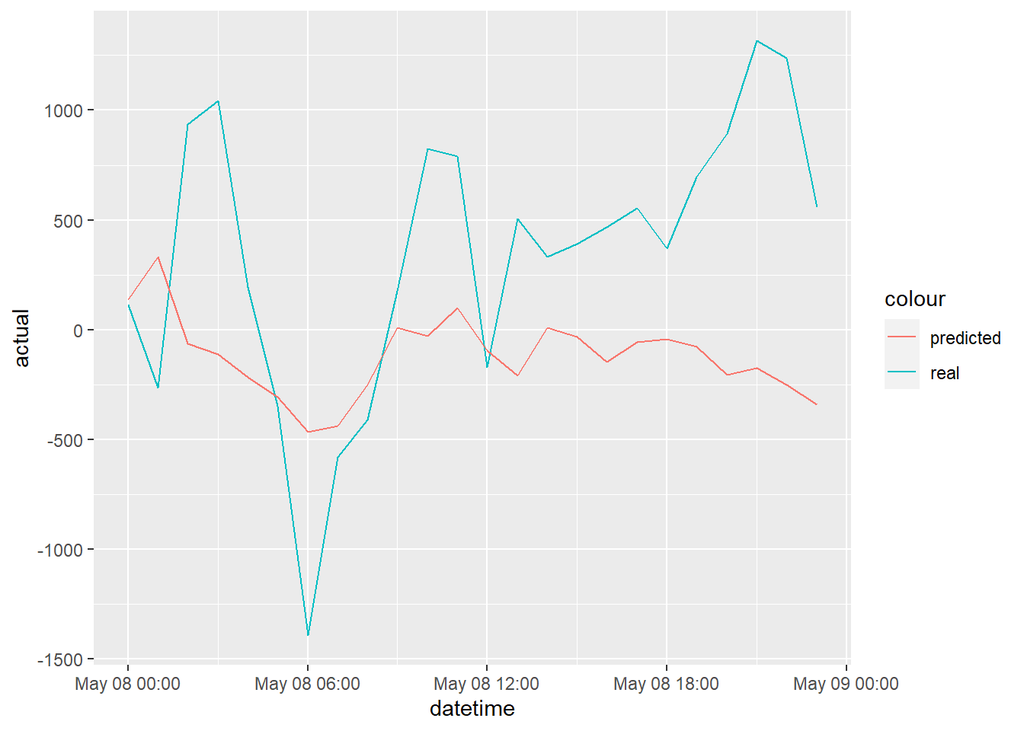

```r
tmp=copy(all)
tmp[,actual:=net]
tmp[,predicted:=predict(lm1,tmp)]
#head(tmp)
ggplot(tmp[Date=='2019-05-08'] ,aes(x=datetime)) +
        geom_line(aes(y=actual,color='real')) +
        geom_line(aes(y=predicted,color='predicted'))
```

Since it does not give a good result, we will start to create a simpler model and develop it with the EBLR method.

### Model2

In this model, we start by using only the values we infer from time

```r
lm2=lm(net~trnd+w_day+mon+hour,all)
summary(lm2)
```

```
##
## Call:
## lm(formula = net ~ trnd + w_day + mon + hour, data = all)
##
## Residuals:
##     Min      1Q  Median      3Q     Max
## -5493.7  -567.6   -27.1   515.8  8522.5
##
## Coefficients:
##               Estimate Std. Error t value Pr(>|t|)
## (Intercept) -1.855e+01  4.059e+01  -0.457 0.647709
## trnd         2.565e-02  8.227e-04  31.177  < 2e-16 ***
## w_dayCum     1.226e+02  2.275e+01   5.387 7.23e-08 ***
## w_dayÇar     1.506e+02  2.276e+01   6.617 3.74e-11 ***
## w_dayPaz    -2.172e+02  2.275e+01  -9.547  < 2e-16 ***
## w_dayPer     1.932e+02  2.275e+01   8.493  < 2e-16 ***
## w_dayPzt     1.049e+02  2.275e+01   4.611 4.03e-06 ***
## w_daySal     1.715e+02  2.272e+01   7.548 4.57e-14 ***
## monAra      -3.697e+02  2.985e+01 -12.385  < 2e-16 ***
## monEki      -3.550e+02  2.977e+01 -11.923  < 2e-16 ***
## monEyl      -4.568e+02  3.000e+01 -15.224  < 2e-16 ***
## monHaz      -2.484e+02  3.002e+01  -8.275  < 2e-16 ***
## monKas      -3.635e+02  3.005e+01 -12.098  < 2e-16 ***
## monMar      -3.813e+02  2.990e+01 -12.753  < 2e-16 ***
## monMay      -4.458e+02  2.980e+01 -14.959  < 2e-16 ***
## monNis      -5.233e+02  3.009e+01 -17.388  < 2e-16 ***
## monOca      -4.160e+02  2.858e+01 -14.558  < 2e-16 ***
## monŞub      -3.171e+02  3.065e+01 -10.347  < 2e-16 ***
## monTem      -1.282e+01  2.976e+01  -0.431 0.666600
## hour1        1.533e+02  4.210e+01   3.641 0.000272 ***
## hour2        8.753e+01  4.210e+01   2.079 0.037632 *
## hour3        3.219e+01  4.210e+01   0.764 0.444603
## hour4       -2.639e+01  4.210e+01  -0.627 0.530742
## hour5       -5.084e+01  4.210e+01  -1.208 0.227222
## hour6       -1.514e+02  4.210e+01  -3.596 0.000323 ***
## hour7       -1.183e+02  4.210e+01  -2.810 0.004956 **
## hour8        5.172e+01  4.210e+01   1.228 0.219281
## hour9        3.096e+02  4.210e+01   7.353 2.00e-13 ***
## hour10       2.894e+02  4.210e+01   6.875 6.34e-12 ***
## hour11       4.229e+02  4.210e+01  10.046  < 2e-16 ***
## hour12       2.260e+02  4.210e+01   5.368 8.02e-08 ***
## hour13       1.560e+02  4.210e+01   3.706 0.000211 ***
## hour14       4.187e+02  4.210e+01   9.944  < 2e-16 ***
## hour15       4.089e+02  4.210e+01   9.711  < 2e-16 ***
## hour16       3.456e+02  4.210e+01   8.208 2.35e-16 ***
## hour17       4.365e+02  4.210e+01  10.368  < 2e-16 ***
## hour18       4.189e+02  4.210e+01   9.950  < 2e-16 ***
## hour19       3.915e+02  4.210e+01   9.299  < 2e-16 ***
## hour20       3.806e+02  4.210e+01   9.039  < 2e-16 ***
## hour21       4.056e+02  4.210e+01   9.633  < 2e-16 ***
## hour22       2.909e+02  4.210e+01   6.909 4.98e-12 ***
## hour23       2.162e+02  4.210e+01   5.134 2.85e-07 ***
## ---
## Signif. codes:  0 '***' 0.001 '**' 0.01 '*' 0.05 '.' 0.1 ' ' 1
##
## Residual standard error: 993.6 on 26694 degrees of freedom
## Multiple R-squared:  0.1078, Adjusted R-squared:  0.1064
## F-statistic: 78.67 on 41 and 26694 DF,  p-value: < 2.2e-16
```

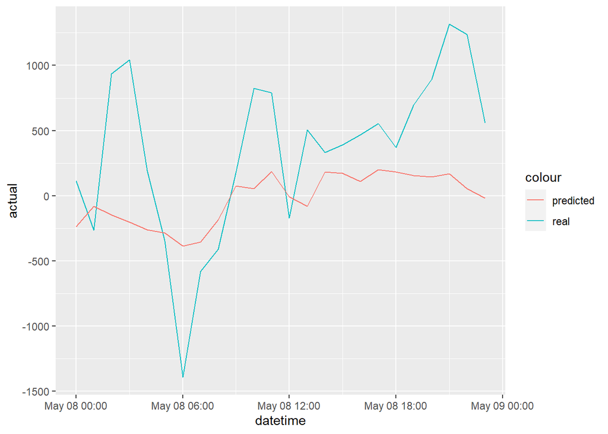

```r
tmp2=copy(all)
tmp2[,actual:=net]
tmp2[,predicted:=predict(lm2,tmp2)]
#head(tmp)
ggplot(tmp2[Date=='2019-05-08'] ,aes(x=datetime)) +
        geom_line(aes(y=actual,color='real')) +
        geom_line(aes(y=predicted,color='predicted'))
```

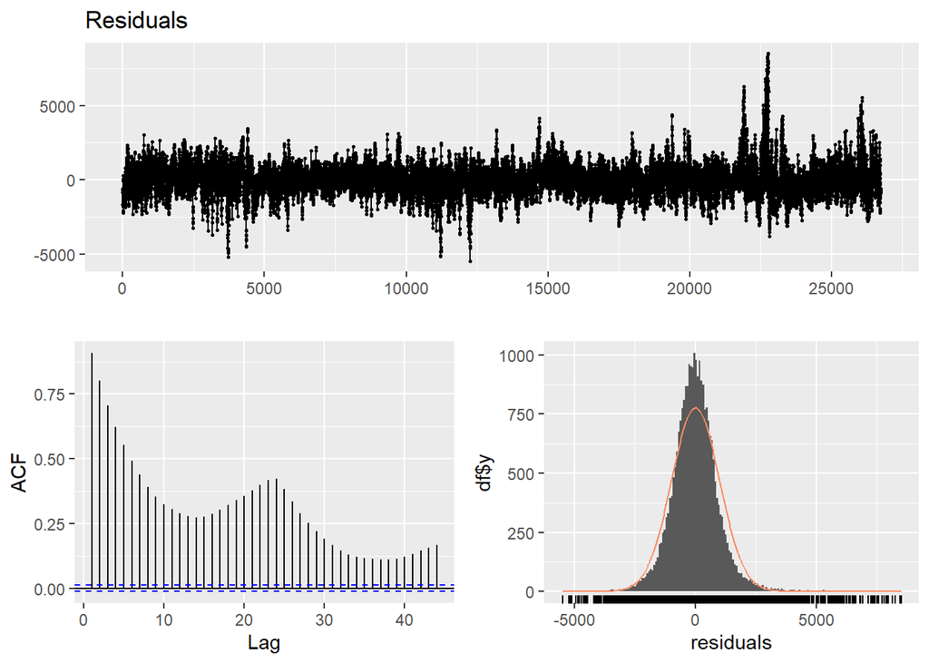

```r
checkresiduals(lm2$residuals)
```

```r
tmp2[,prevday:=shift(x=tmp2$net,n=24L,fill=mean(tmp2$net))]
tmp2[,prevweek:=shift(x=tmp2$net,n=168L,fill=mean(tmp2$net))]
head(tmp2)
```

```
##               datetime       net system_direction loc1_DSWRF_surface
## 1: 2019-01-01 00:00:00 -1934.795         Negative                  0
## 2: 2019-01-01 01:00:00  -750.866         Negative                  0
## 3: 2019-01-01 02:00:00  -982.767         Negative                  0
## 4: 2019-01-01 03:00:00  -764.620         Negative                  0
## 5: 2019-01-01 04:00:00 -1233.289         Negative                  0
## 6: 2019-01-01 05:00:00 -1469.061         Negative                  0
##    loc1_RH_2.m.above.ground loc1_TCDC_low.cloud.layer loc1_TMP_2.m.above.ground
## 1:                 84.20000                   0.00000                    -4.081
## 2:                 84.43333                   3.00000                    -3.707
## 3:                 84.66667                   6.00000                    -3.333
## 4:                 84.90000                   9.00000                    -2.959
## 5:                 87.26667                  29.66667                    -2.591
## 6:                 89.63333                  50.33333                    -2.223
##    loc1_wdir_10m loc1_ws_10m loc2_DSWRF_surface loc2_RH_2.m.above.ground
```

[output cut: 97 more lines]

### Improvements

First, we add prevday and prevweek values to our previous model. Then, we examine the residuals of this new model on the tree.

```r
lm2_1=lm(net~trnd+w_day+mon+hour+prevday+prevweek,
                 tmp2)
summary(lm2_1)
```

```
##
## Call:
## lm(formula = net ~ trnd + w_day + mon + hour + prevday + prevweek,
##     data = tmp2)
##
## Residuals:
##     Min      1Q  Median      3Q     Max
## -5878.8  -522.1   -10.4   500.8  6636.9
##
## Coefficients:
##               Estimate Std. Error t value Pr(>|t|)
## (Intercept) -7.659e+01  3.663e+01  -2.091 0.036558 *
## trnd         1.308e-02  7.659e-04  17.074  < 2e-16 ***
## w_dayCum     8.327e+01  2.054e+01   4.054 5.06e-05 ***
## w_dayÇar     1.156e+02  2.055e+01   5.623 1.89e-08 ***
## w_dayPaz    -1.513e+02  2.057e+01  -7.356 1.95e-13 ***
## w_dayPer     1.672e+02  2.056e+01   8.133 4.38e-16 ***
## w_dayPzt     2.398e+02  2.063e+01  11.623  < 2e-16 ***
## w_daySal     1.636e+02  2.052e+01   7.973 1.61e-15 ***
## monAra      -1.855e+02  2.706e+01  -6.856 7.24e-12 ***
## monEki      -1.604e+02  2.703e+01  -5.934 3.00e-09 ***
## monEyl      -2.306e+02  2.726e+01  -8.461  < 2e-16 ***
## monHaz      -8.817e+01  2.724e+01  -3.237 0.001210 **
## monKas      -1.671e+02  2.728e+01  -6.123 9.32e-10 ***
## monMar      -1.854e+02  2.715e+01  -6.829 8.70e-12 ***
## monMay      -1.915e+02  2.718e+01  -7.043 1.93e-12 ***
## monNis      -2.547e+02  2.744e+01  -9.281  < 2e-16 ***
## monOca      -1.908e+02  2.601e+01  -7.334 2.30e-13 ***
## monŞub      -1.411e+02  2.780e+01  -5.073 3.93e-07 ***
## monTem       6.955e+00  2.685e+01   0.259 0.795654
## hour1        7.780e+01  3.801e+01   2.047 0.040674 *
## hour2        4.449e+01  3.800e+01   1.171 0.241695
## hour3        1.601e+01  3.799e+01   0.422 0.673385
## hour4       -1.330e+01  3.799e+01  -0.350 0.726387
## hour5       -2.551e+01  3.799e+01  -0.672 0.501875
## hour6       -7.596e+01  3.801e+01  -1.999 0.045672 *
## hour7       -5.937e+01  3.800e+01  -1.562 0.118241
## hour8        2.704e+01  3.799e+01   0.712 0.476584
## hour9        1.577e+02  3.806e+01   4.143 3.44e-05 ***
## hour10       1.469e+02  3.805e+01   3.860 0.000114 ***
## hour11       2.143e+02  3.812e+01   5.621 1.91e-08 ***
## hour12       1.146e+02  3.803e+01   3.014 0.002577 **
## hour13       7.928e+01  3.801e+01   2.086 0.037020 *
## hour14       2.120e+02  3.812e+01   5.562 2.69e-08 ***
## hour15       2.070e+02  3.812e+01   5.431 5.65e-08 ***
## hour16       1.749e+02  3.808e+01   4.594 4.37e-06 ***
## hour17       2.210e+02  3.813e+01   5.796 6.85e-09 ***
## hour18       2.122e+02  3.812e+01   5.568 2.61e-08 ***
## hour19       1.983e+02  3.811e+01   5.205 1.96e-07 ***
## hour20       1.927e+02  3.810e+01   5.058 4.26e-07 ***
## hour21       2.053e+02  3.811e+01   5.387 7.21e-08 ***
## hour22       1.474e+02  3.805e+01   3.874 0.000107 ***
## hour23       1.098e+02  3.803e+01   2.888 0.003874 **
## prevday      4.188e-01  5.550e-03  75.464  < 2e-16 ***
## prevweek     7.586e-02  5.552e-03  13.662  < 2e-16 ***
## ---
## Signif. codes:  0 '***' 0.001 '**' 0.01 '*' 0.05 '.' 0.1 ' ' 1
##
## Residual standard error: 896.6 on 26692 degrees of freedom
## Multiple R-squared:  0.2736, Adjusted R-squared:  0.2724
## F-statistic: 233.8 on 43 and 26692 DF,  p-value: < 2.2e-16
```

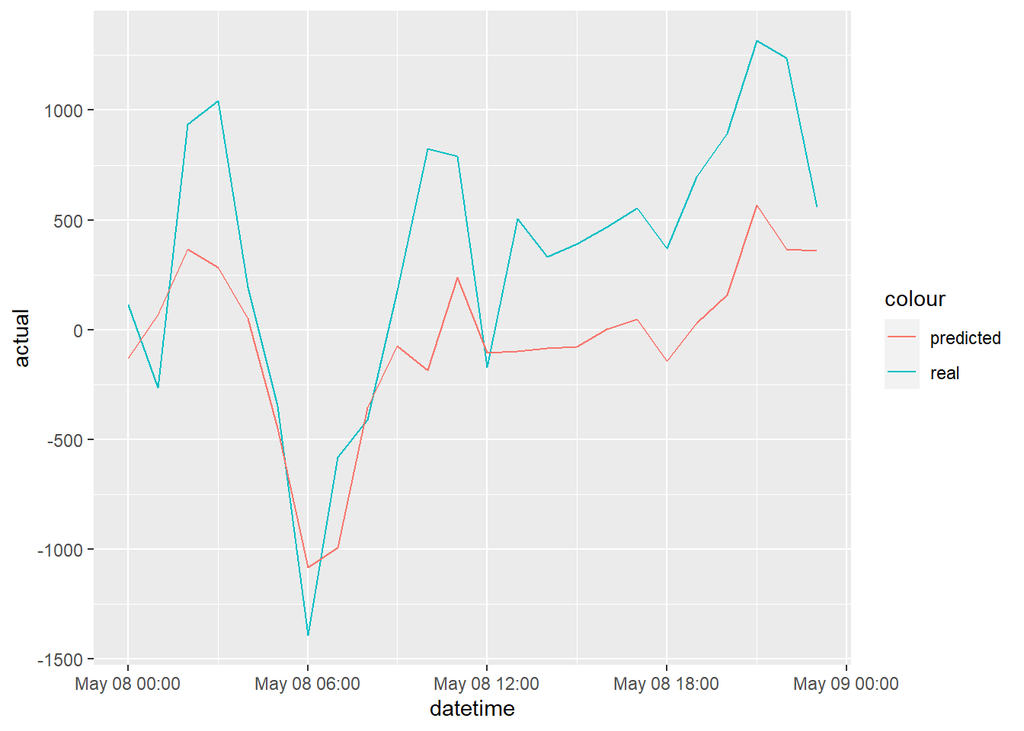

```r
tmp2[,predicted:=predict(lm2_1,tmp2)]
#head(tmp)
ggplot(tmp2[Date=='2019-05-08'] ,aes(x=datetime)) +
        geom_line(aes(y=actual,color='real')) +
        geom_line(aes(y=predicted,color='predicted'))
```

[figure not shown]

```r
tmp2[,residual:=actual-predicted]


fit_res_tree=rpart(residual~w_day+mon+hour+prevday+prevweek+
         loc1_DSWRF_surface+loc1_RH_2.m.above.ground+loc1_TCDC_low.cloud.layer+loc1_TMP_2.m.above.ground+loc1_wdir_10m+loc1_ws_10m+
         loc2_DSWRF_surface+loc2_RH_2.m.above.ground+loc2_TCDC_low.cloud.layer+loc2_TMP_2.m.above.ground+loc2_wdir_10m+loc2_ws_10m+
         loc3_DSWRF_surface+loc3_RH_2.m.above.ground+loc3_TCDC_low.cloud.layer+loc3_TMP_2.m.above.ground+loc3_wdir_10m+loc3_ws_10m+
         loc4_DSWRF_surface+loc4_RH_2.m.above.ground+loc4_TCDC_low.cloud.layer+loc4_TMP_2.m.above.ground+loc4_wdir_10m+loc4_ws_10m+
         loc5_DSWRF_surface+loc5_RH_2.m.above.ground+loc5_TCDC_low.cloud.layer+loc5_TMP_2.m.above.ground+loc5_wdir_10m+loc5_ws_10m+
         loc6_DSWRF_surface+loc6_RH_2.m.above.ground+loc6_TCDC_low.cloud.layer+loc6_TMP_2.m.above.ground+loc6_wdir_10m+loc6_ws_10m+
         loc7_DSWRF_surface+loc7_RH_2.m.above.ground+loc7_TCDC_low.cloud.layer+loc7_TMP_2.m.above.ground+loc7_wdir_10m+loc7_ws_10m,tmp2,
                   control=rpart.control(cp=0,maxdepth=3))

fancyRpartPlot(fit_res_tree)
```

As seen in the tree, the rightmost path causes many errors. That’s why we focus on this part first.And we add our newly created decision variables to the model.Thus, we obtain a new model with better results. Then, we re-examine the residual values of this new model by creating a tree.

We repeat this process until our improvement is very low. The process: -Create a model -Examine the tree for residuals -Create decision variables cause many errors -Add the decision varianles to model and re-evaluate the new model

```r
tmp2[,loc7tmp2ag:=as.numeric(loc7_TMP_2.m.above.ground>=30)]
tmp2[,pv:=as.numeric(prevweek>=2070)]
tmp2[,loc7tmp2ag2:=as.numeric(loc7_TMP_2.m.above.ground>=31)]

lm2_2=lm(net~trnd+w_day+mon+hour+prevday+prevweek+loc7tmp2ag:pv:loc7tmp2ag2,
                 tmp2)
summary(lm2_2)
```

```
##
## Call:
## lm(formula = net ~ trnd + w_day + mon + hour + prevday + prevweek +
##     loc7tmp2ag:pv:loc7tmp2ag2, data = tmp2)
##
## Residuals:
##     Min      1Q  Median      3Q     Max
## -5547.4  -517.0    -7.5   499.8  5796.0
##
## Coefficients:
##                             Estimate Std. Error t value Pr(>|t|)
## (Intercept)               -1.129e+02  3.603e+01  -3.133 0.001733 **
## trnd                       1.322e-02  7.529e-04  17.565  < 2e-16 ***
## w_dayCum                   7.843e+01  2.019e+01   3.884 0.000103 ***
## w_dayÇar                   1.114e+02  2.020e+01   5.514 3.53e-08 ***
## w_dayPaz                  -1.569e+02  2.022e+01  -7.757 9.00e-15 ***
## w_dayPer                   1.555e+02  2.021e+01   7.693 1.49e-14 ***
## w_dayPzt                   2.230e+02  2.029e+01  10.992  < 2e-16 ***
## w_daySal                   1.609e+02  2.017e+01   7.976 1.58e-15 ***
## monAra                    -1.332e+02  2.666e+01  -4.995 5.92e-07 ***
## monEki                    -1.106e+02  2.662e+01  -4.153 3.30e-05 ***
## monEyl                    -1.829e+02  2.684e+01  -6.816 9.57e-12 ***
## monHaz                    -3.887e+01  2.682e+01  -1.449 0.147326
## monKas                    -1.169e+02  2.687e+01  -4.350 1.37e-05 ***
## monMar                    -1.399e+02  2.673e+01  -5.233 1.68e-07 ***
## monMay                    -1.492e+02  2.676e+01  -5.577 2.46e-08 ***
## monNis                    -2.134e+02  2.701e+01  -7.900 2.90e-15 ***
## monOca                    -1.462e+02  2.561e+01  -5.707 1.16e-08 ***
## monŞub                    -9.475e+01  2.737e+01  -3.461 0.000538 ***
## monTem                     6.181e+01  2.646e+01   2.336 0.019483 *
## hour1                      8.348e+01  3.736e+01   2.234 0.025470 *
## hour2                      4.773e+01  3.735e+01   1.278 0.201328
## hour3                      1.724e+01  3.735e+01   0.462 0.644415
## hour4                     -1.427e+01  3.735e+01  -0.382 0.702414
## hour5                     -2.741e+01  3.735e+01  -0.734 0.463009
## hour6                     -8.164e+01  3.736e+01  -2.185 0.028889 *
## hour7                     -6.380e+01  3.736e+01  -1.708 0.087670 .
## hour8                      2.890e+01  3.735e+01   0.774 0.439082
## hour9                      1.691e+02  3.742e+01   4.520 6.22e-06 ***
## hour10                     1.576e+02  3.741e+01   4.214 2.52e-05 ***
## hour11                     2.213e+02  3.748e+01   5.905 3.58e-09 ***
## hour12                     1.143e+02  3.738e+01   3.057 0.002235 **
## hour13                     7.632e+01  3.736e+01   2.043 0.041085 *
## hour14                     2.101e+02  3.747e+01   5.607 2.08e-08 ***
## hour15                     1.960e+02  3.747e+01   5.231 1.70e-07 ***
## hour16                     1.660e+02  3.743e+01   4.433 9.32e-06 ***
## hour17                     2.198e+02  3.748e+01   5.863 4.59e-09 ***
## hour18                     2.191e+02  3.747e+01   5.846 5.09e-09 ***
## hour19                     2.085e+02  3.746e+01   5.567 2.62e-08 ***
## hour20                     1.981e+02  3.745e+01   5.290 1.23e-07 ***
## hour21                     2.117e+02  3.747e+01   5.650 1.62e-08 ***
## hour22                     1.583e+02  3.741e+01   4.231 2.34e-05 ***
## hour23                     1.179e+02  3.738e+01   3.153 0.001618 **
## prevday                    3.925e-01  5.523e-03  71.062  < 2e-16 ***
## prevweek                   6.493e-02  5.470e-03  11.871  < 2e-16 ***
## loc7tmp2ag:pv:loc7tmp2ag2  4.873e+03  1.595e+02  30.549  < 2e-16 ***
## ---
## Signif. codes:  0 '***' 0.001 '**' 0.01 '*' 0.05 '.' 0.1 ' ' 1
##
## Residual standard error: 881.4 on 26691 degrees of freedom
## Multiple R-squared:  0.2981, Adjusted R-squared:  0.2969
## F-statistic: 257.6 on 44 and 26691 DF,  p-value: < 2.2e-16
```

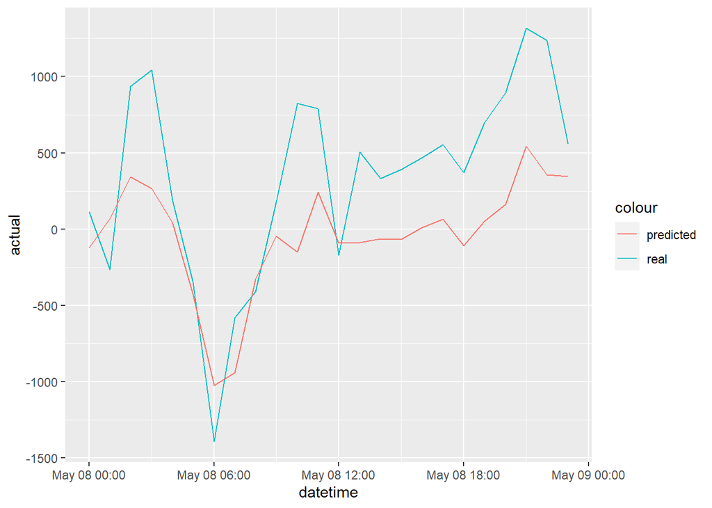

```r
tmp2[,predicted:=predict(lm2_2,tmp2)]
#head(tmp)
ggplot(tmp2[Date=='2019-05-08'] ,aes(x=datetime)) +
        geom_line(aes(y=actual,color='real')) +
        geom_line(aes(y=predicted,color='predicted'))
```

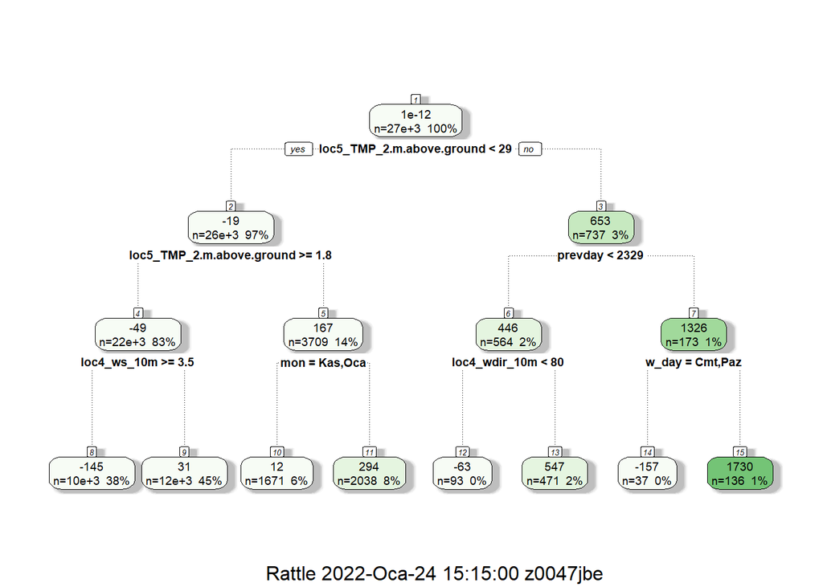

```r
tmp2[,residual:=actual-predicted]


fit_res_tree=rpart(residual~w_day+mon+hour+prevday+prevweek+
         loc1_DSWRF_surface+loc1_RH_2.m.above.ground+loc1_TCDC_low.cloud.layer+loc1_TMP_2.m.above.ground+loc1_wdir_10m+loc1_ws_10m+
         loc2_DSWRF_surface+loc2_RH_2.m.above.ground+loc2_TCDC_low.cloud.layer+loc2_TMP_2.m.above.ground+loc2_wdir_10m+loc2_ws_10m+
         loc3_DSWRF_surface+loc3_RH_2.m.above.ground+loc3_TCDC_low.cloud.layer+loc3_TMP_2.m.above.ground+loc3_wdir_10m+loc3_ws_10m+
         loc4_DSWRF_surface+loc4_RH_2.m.above.ground+loc4_TCDC_low.cloud.layer+loc4_TMP_2.m.above.ground+loc4_wdir_10m+loc4_ws_10m+
         loc5_DSWRF_surface+loc5_RH_2.m.above.ground+loc5_TCDC_low.cloud.layer+loc5_TMP_2.m.above.ground+loc5_wdir_10m+loc5_ws_10m+
         loc6_DSWRF_surface+loc6_RH_2.m.above.ground+loc6_TCDC_low.cloud.layer+loc6_TMP_2.m.above.ground+loc6_wdir_10m+loc6_ws_10m+
         loc7_DSWRF_surface+loc7_RH_2.m.above.ground+loc7_TCDC_low.cloud.layer+loc7_wdir_10m+loc7_ws_10m,tmp2,
                   control=rpart.control(cp=0,maxdepth=3))

fancyRpartPlot(fit_res_tree)
```

```r
tmp2[,loc5tmp2ag:=as.numeric(loc5_TMP_2.m.above.ground>=29)]
tmp2[,pd:=as.numeric(prevday>=2329)]
tmp2[,workday:=as.numeric(!w_day %in% c('Cmt','Paz'))]

lm2_3=lm(net~trnd+w_day+mon+hour+prevday+prevweek+loc7tmp2ag:pv:loc7tmp2ag2+loc5tmp2ag:pd:workday,
                 tmp2)
summary(lm2_3)
```

```
##
## Call:
## lm(formula = net ~ trnd + w_day + mon + hour + prevday + prevweek +
##     loc7tmp2ag:pv:loc7tmp2ag2 + loc5tmp2ag:pd:workday, data = tmp2)
##
## Residuals:
##     Min      1Q  Median      3Q     Max
## -5188.5  -513.5    -5.6   496.6  5821.1
##
## Coefficients:
##                             Estimate Std. Error t value Pr(>|t|)
## (Intercept)               -1.251e+02  3.562e+01  -3.512 0.000446 ***
## trnd                       1.339e-02  7.442e-04  17.986  < 2e-16 ***
## w_dayCum                   5.626e+01  1.998e+01   2.816 0.004868 **
## w_dayÇar                   9.650e+01  1.998e+01   4.830 1.37e-06 ***
## w_dayPaz                  -1.612e+02  1.999e+01  -8.062 7.80e-16 ***
## w_dayPer                   1.396e+02  1.999e+01   6.986 2.90e-12 ***
## w_dayPzt                   2.133e+02  2.006e+01  10.638  < 2e-16 ***
## w_daySal                   1.517e+02  1.994e+01   7.604 2.96e-14 ***
## monAra                    -9.816e+01  2.639e+01  -3.720 0.000200 ***
## monEki                    -7.698e+01  2.635e+01  -2.921 0.003487 **
## monEyl                    -1.737e+02  2.653e+01  -6.548 5.93e-11 ***
## monHaz                    -1.532e+01  2.653e+01  -0.577 0.563656
## monKas                    -8.344e+01  2.659e+01  -3.137 0.001706 **
## monMar                    -1.108e+02  2.645e+01  -4.189 2.82e-05 ***
## monMay                    -1.228e+02  2.647e+01  -4.640 3.51e-06 ***
## monNis                    -1.886e+02  2.672e+01  -7.058 1.73e-12 ***
## monOca                    -1.178e+02  2.534e+01  -4.647 3.39e-06 ***
## monŞub                    -6.436e+01  2.708e+01  -2.377 0.017484 *
## monTem                     7.036e+01  2.615e+01   2.690 0.007148 **
## hour1                      8.885e+01  3.693e+01   2.406 0.016150 *
## hour2                      5.079e+01  3.692e+01   1.376 0.168977
## hour3                      1.838e+01  3.692e+01   0.498 0.618476
## hour4                     -1.520e+01  3.692e+01  -0.412 0.680451
## hour5                     -2.921e+01  3.692e+01  -0.791 0.428799
## hour6                     -8.699e+01  3.693e+01  -2.355 0.018512 *
## hour7                     -6.798e+01  3.693e+01  -1.841 0.065633 .
## hour8                      3.066e+01  3.692e+01   0.831 0.406177
## hour9                      1.799e+02  3.699e+01   4.864 1.16e-06 ***
## hour10                     1.659e+02  3.698e+01   4.487 7.24e-06 ***
```

[output cut: 8 more lines]

```
## hour19                     2.085e+02  3.703e+01   5.632 1.80e-08 ***
## hour20                     2.132e+02  3.702e+01   5.759 8.56e-09 ***
## hour21                     2.277e+02  3.704e+01   6.147 8.03e-10 ***
## hour22                     1.685e+02  3.698e+01   4.555 5.25e-06 ***
## hour23                     1.254e+02  3.695e+01   3.394 0.000689 ***
## prevday                    3.582e-01  5.628e-03  63.647  < 2e-16 ***
## prevweek                   6.410e-02  5.407e-03  11.857  < 2e-16 ***
## loc7tmp2ag:pv:loc7tmp2ag2  3.896e+03  1.624e+02  23.993  < 2e-16 ***
## loc5tmp2ag:pd:workday      2.031e+03  8.106e+01  25.054  < 2e-16 ***
## ---
## Signif. codes:  0 '***' 0.001 '**' 0.01 '*' 0.05 '.' 0.1 ' ' 1
##
## Residual standard error: 871.2 on 26690 degrees of freedom
## Multiple R-squared:  0.3142, Adjusted R-squared:  0.3131
## F-statistic: 271.8 on 45 and 26690 DF,  p-value: < 2.2e-16
```

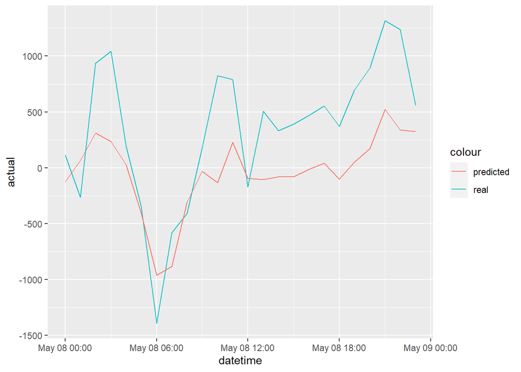

```r
tmp2[,predicted:=predict(lm2_3,tmp2)]
#head(tmp)
ggplot(tmp2[Date=='2019-05-08'] ,aes(x=datetime)) +
        geom_line(aes(y=actual,color='real')) +
        geom_line(aes(y=predicted,color='predicted'))
```

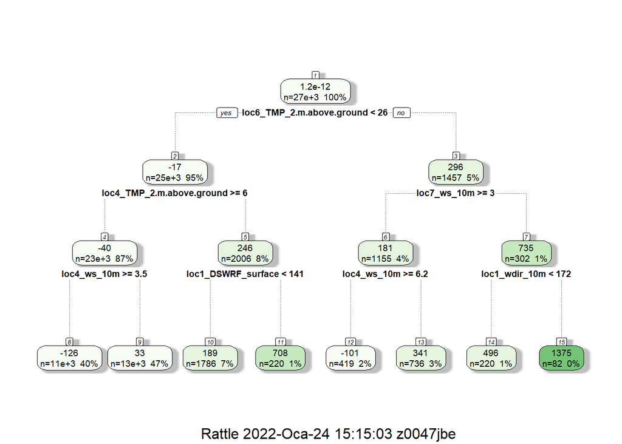

```r
tmp2[,residual:=actual-predicted]


fit_res_tree=rpart(residual~mon+hour+
         loc1_DSWRF_surface+loc1_RH_2.m.above.ground+loc1_TCDC_low.cloud.layer+loc1_TMP_2.m.above.ground+loc1_wdir_10m+loc1_ws_10m+
         loc2_DSWRF_surface+loc2_RH_2.m.above.ground+loc2_TCDC_low.cloud.layer+loc2_TMP_2.m.above.ground+loc2_wdir_10m+loc2_ws_10m+
         loc3_DSWRF_surface+loc3_RH_2.m.above.ground+loc3_TCDC_low.cloud.layer+loc3_TMP_2.m.above.ground+loc3_wdir_10m+loc3_ws_10m+
         loc4_DSWRF_surface+loc4_RH_2.m.above.ground+loc4_TCDC_low.cloud.layer+loc4_TMP_2.m.above.ground+loc4_wdir_10m+loc4_ws_10m+
         loc5_DSWRF_surface+loc5_RH_2.m.above.ground+loc5_TCDC_low.cloud.layer+loc5_wdir_10m+loc5_ws_10m+
         loc6_DSWRF_surface+loc6_RH_2.m.above.ground+loc6_TCDC_low.cloud.layer+loc6_TMP_2.m.above.ground+loc6_wdir_10m+loc6_ws_10m+
         loc7_DSWRF_surface+loc7_RH_2.m.above.ground+loc7_TCDC_low.cloud.layer+loc7_wdir_10m+loc7_ws_10m,tmp2,
                   control=rpart.control(cp=0,maxdepth=3))

fancyRpartPlot(fit_res_tree)
```

```r
tmp2[,loc4tmp2ag:=as.numeric(loc4_TMP_2.m.above.ground<8.6)]
tmp2[,whour:=as.numeric(as.numeric(hour)<9 | as.numeric(hour)>18)]
tmp2[,loc3wdir:=as.numeric(loc3_wdir_10m<336)]

lm2_4=lm(net~trnd+w_day+mon+hour+prevday+prevweek+loc7tmp2ag:pv:loc7tmp2ag2+loc5tmp2ag:pd:workday+loc4tmp2ag:whour:loc3wdir,
                 tmp2)
summary(lm2_4)
```

```
##
## Call:
## lm(formula = net ~ trnd + w_day + mon + hour + prevday + prevweek +
##     loc7tmp2ag:pv:loc7tmp2ag2 + loc5tmp2ag:pd:workday + loc4tmp2ag:whour:loc3wdir,
##     data = tmp2)
##
## Residuals:
##     Min      1Q  Median      3Q     Max
## -5187.4  -508.6    -8.5   496.7  5805.1
##
## Coefficients:
##                             Estimate Std. Error t value Pr(>|t|)
## (Intercept)               -1.343e+02  3.561e+01  -3.772 0.000162 ***
## trnd                       1.333e-02  7.435e-04  17.929  < 2e-16 ***
## w_dayCum                   5.411e+01  1.996e+01   2.710 0.006731 **
## w_dayÇar                   9.734e+01  1.996e+01   4.877 1.08e-06 ***
## w_dayPaz                  -1.613e+02  1.997e+01  -8.077 6.89e-16 ***
## w_dayPer                   1.386e+02  1.997e+01   6.940 4.02e-12 ***
## w_dayPzt                   2.138e+02  2.004e+01  10.672  < 2e-16 ***
## w_daySal                   1.543e+02  1.993e+01   7.742 1.02e-14 ***
## monAra                    -1.277e+02  2.669e+01  -4.787 1.70e-06 ***
## monEki                    -7.792e+01  2.633e+01  -2.960 0.003081 **
## monEyl                    -1.748e+02  2.651e+01  -6.594 4.37e-11 ***
## monHaz                    -1.652e+01  2.651e+01  -0.623 0.533090
## monKas                    -9.349e+01  2.661e+01  -3.514 0.000442 ***
## monMar                    -1.423e+02  2.679e+01  -5.312 1.09e-07 ***
## monMay                    -1.244e+02  2.645e+01  -4.704 2.57e-06 ***
## monNis                    -2.027e+02  2.677e+01  -7.573 3.76e-14 ***
## monOca                    -1.651e+02  2.617e+01  -6.309 2.85e-10 ***
## monŞub                    -1.073e+02  2.772e+01  -3.872 0.000108 ***
## monTem                     7.017e+01  2.613e+01   2.685 0.007248 **
## hour1                      8.815e+01  3.690e+01   2.389 0.016902 *
## hour2                      4.953e+01  3.689e+01   1.343 0.179337
## hour3                      1.501e+01  3.688e+01   0.407 0.684070
## hour4                     -1.938e+01  3.689e+01  -0.526 0.599217
## hour5                     -3.544e+01  3.689e+01  -0.961 0.336695
## hour6                     -9.440e+01  3.691e+01  -2.557 0.010554 *
## hour7                     -7.663e+01  3.691e+01  -2.076 0.037884 *
## hour8                      5.629e+01  3.706e+01   1.519 0.128728
## hour9                      2.062e+02  3.713e+01   5.552 2.86e-08 ***
```

[output cut: 10 more lines]

```
## hour20                     2.213e+02  3.701e+01   5.980 2.26e-09 ***
## hour21                     2.339e+02  3.702e+01   6.320 2.65e-10 ***
## hour22                     1.727e+02  3.695e+01   4.675 2.95e-06 ***
## hour23                     1.270e+02  3.692e+01   3.440 0.000582 ***
## prevday                    3.568e-01  5.627e-03  63.408  < 2e-16 ***
## prevweek                   6.315e-02  5.403e-03  11.688  < 2e-16 ***
## loc7tmp2ag:pv:loc7tmp2ag2  3.899e+03  1.622e+02  24.031  < 2e-16 ***
## loc5tmp2ag:pd:workday      2.025e+03  8.099e+01  25.002  < 2e-16 ***
## loc4tmp2ag:whour:loc3wdir  1.480e+02  2.072e+01   7.143 9.34e-13 ***
## ---
## Signif. codes:  0 '***' 0.001 '**' 0.01 '*' 0.05 '.' 0.1 ' ' 1
##
## Residual standard error: 870.4 on 26689 degrees of freedom
## Multiple R-squared:  0.3155, Adjusted R-squared:  0.3144
## F-statistic: 267.5 on 46 and 26689 DF,  p-value: < 2.2e-16
```

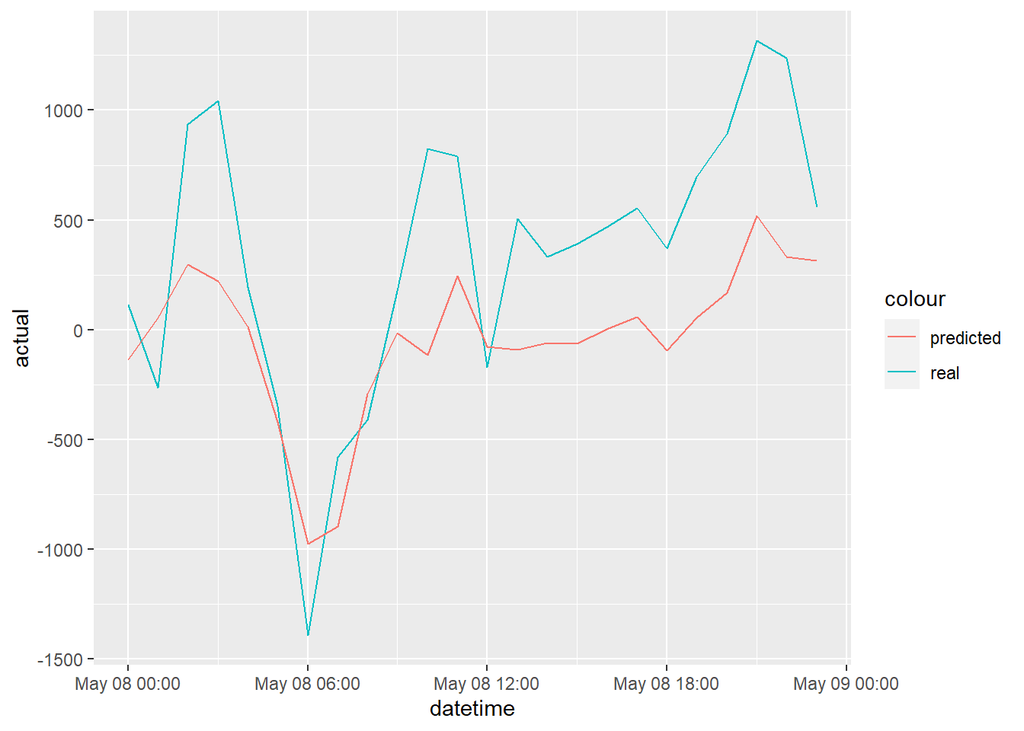

```r
tmp2[,predicted:=predict(lm2_4,tmp2)]
#head(tmp)
ggplot(tmp2[Date=='2019-05-08'] ,aes(x=datetime)) +
        geom_line(aes(y=actual,color='real')) +
        geom_line(aes(y=predicted,color='predicted'))
```

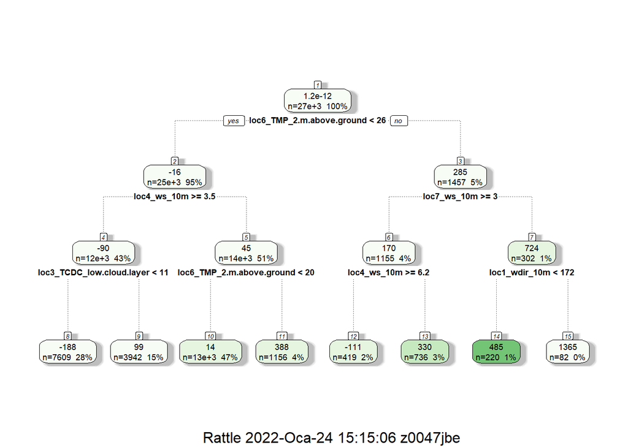

```r
tmp2[,residual:=actual-predicted]


fit_res_tree=rpart(residual~mon+
         loc1_DSWRF_surface+loc1_RH_2.m.above.ground+loc1_TCDC_low.cloud.layer+loc1_TMP_2.m.above.ground+loc1_wdir_10m+loc1_ws_10m+
         loc2_DSWRF_surface+loc2_RH_2.m.above.ground+loc2_TCDC_low.cloud.layer+loc2_TMP_2.m.above.ground+loc2_wdir_10m+loc2_ws_10m+
         loc3_DSWRF_surface+loc3_RH_2.m.above.ground+loc3_TCDC_low.cloud.layer+loc3_TMP_2.m.above.ground+loc3_ws_10m+
         loc4_DSWRF_surface+loc4_RH_2.m.above.ground+loc4_TCDC_low.cloud.layer+loc4_wdir_10m+loc4_ws_10m+
         loc5_DSWRF_surface+loc5_RH_2.m.above.ground+loc5_TCDC_low.cloud.layer+loc5_wdir_10m+loc5_ws_10m+
         loc6_DSWRF_surface+loc6_RH_2.m.above.ground+loc6_TCDC_low.cloud.layer+loc6_TMP_2.m.above.ground+loc6_wdir_10m+loc6_ws_10m+
         loc7_DSWRF_surface+loc7_RH_2.m.above.ground+loc7_TCDC_low.cloud.layer+loc7_wdir_10m+loc7_ws_10m,tmp2,
                   control=rpart.control(cp=0,maxdepth=3))

fancyRpartPlot(fit_res_tree)
```

```r
tmp2[,loc6tmp2ag:=as.numeric(loc6_TMP_2.m.above.ground>=26)]
tmp2[,loc7ws:=as.numeric(loc7_ws_10m<3)]
tmp2[,loc1wdir:=as.numeric(loc1_wdir_10m>=172)]

lm2_5=lm(net~trnd+w_day+mon+hour+prevday+prevweek+loc7tmp2ag:pv:loc7tmp2ag2+loc5tmp2ag:pd:workday+loc4tmp2ag:whour:loc3wdir+loc6tmp2ag:loc7ws:loc1wdir,
                 tmp2)
summary(lm2_5)
```

```
##
## Call:
## lm(formula = net ~ trnd + w_day + mon + hour + prevday + prevweek +
##     loc7tmp2ag:pv:loc7tmp2ag2 + loc5tmp2ag:pd:workday + loc4tmp2ag:whour:loc3wdir +
##     loc6tmp2ag:loc7ws:loc1wdir, data = tmp2)
##
## Residuals:
##     Min      1Q  Median      3Q     Max
## -5128.8  -507.7    -6.0   498.4  5044.6
##
## Coefficients:
##                              Estimate Std. Error t value Pr(>|t|)
## (Intercept)                -1.440e+02  3.546e+01  -4.063 4.87e-05 ***
## trnd                        1.307e-02  7.404e-04  17.658  < 2e-16 ***
## w_dayCum                    5.592e+01  1.988e+01   2.814 0.004904 **
## w_dayÇar                    9.977e+01  1.987e+01   5.021 5.17e-07 ***
## w_dayPaz                   -1.617e+02  1.988e+01  -8.130 4.49e-16 ***
## w_dayPer                    1.403e+02  1.988e+01   7.057 1.74e-12 ***
## w_dayPzt                    2.093e+02  1.995e+01  10.492  < 2e-16 ***
## w_daySal                    1.519e+02  1.984e+01   7.654 2.01e-14 ***
## monAra                     -1.077e+02  2.660e+01  -4.049 5.17e-05 ***
## monEki                     -6.542e+01  2.622e+01  -2.495 0.012600 *
## monEyl                     -1.562e+02  2.642e+01  -5.914 3.38e-09 ***
## monHaz                     -1.484e+00  2.641e+01  -0.056 0.955181
## monKas                     -7.435e+01  2.652e+01  -2.804 0.005054 **
## monMar                     -1.247e+02  2.669e+01  -4.670 3.03e-06 ***
## monMay                     -1.111e+02  2.634e+01  -4.218 2.47e-05 ***
## monNis                     -1.861e+02  2.667e+01  -6.978 3.07e-12 ***
## monOca                     -1.468e+02  2.608e+01  -5.629 1.84e-08 ***
## monŞub                     -8.945e+01  2.762e+01  -3.239 0.001203 **
## monTem                      7.503e+01  2.602e+01   2.884 0.003930 **
## hour1                       8.885e+01  3.673e+01   2.419 0.015578 *
## hour2                       4.996e+01  3.672e+01   1.361 0.173678
## hour3                       1.527e+01  3.672e+01   0.416 0.677624
## hour4                      -1.937e+01  3.672e+01  -0.527 0.597940
## hour5                      -3.547e+01  3.673e+01  -0.966 0.334205
## hour6                      -9.484e+01  3.675e+01  -2.581 0.009867 **
## hour7                      -7.688e+01  3.675e+01  -2.092 0.036426 *
## hour8                       5.569e+01  3.689e+01   1.510 0.131162
## hour9                       2.040e+02  3.697e+01   5.519 3.44e-08 ***
```

[output cut: 11 more lines]

```
## hour21                      2.363e+02  3.685e+01   6.411 1.47e-10 ***
## hour22                      1.726e+02  3.679e+01   4.692 2.72e-06 ***
## hour23                      1.279e+02  3.675e+01   3.481 0.000501 ***
## prevday                     3.529e-01  5.607e-03  62.947  < 2e-16 ***
## prevweek                    6.258e-02  5.379e-03  11.634  < 2e-16 ***
## loc7tmp2ag:pv:loc7tmp2ag2   3.511e+03  1.635e+02  21.479  < 2e-16 ***
## loc5tmp2ag:pd:workday       1.898e+03  8.104e+01  23.419  < 2e-16 ***
## loc4tmp2ag:whour:loc3wdir   1.432e+02  2.063e+01   6.942 3.95e-12 ***
## loc6tmp2ag:loc7ws:loc1wdir  1.476e+03  9.545e+01  15.460  < 2e-16 ***
## ---
## Signif. codes:  0 '***' 0.001 '**' 0.01 '*' 0.05 '.' 0.1 ' ' 1
##
## Residual standard error: 866.5 on 26688 degrees of freedom
## Multiple R-squared:  0.3216, Adjusted R-squared:  0.3204
## F-statistic: 269.2 on 47 and 26688 DF,  p-value: < 2.2e-16
```

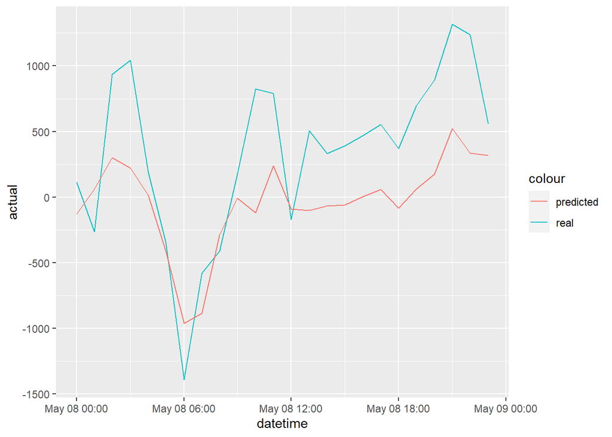

```r
tmp2[,predicted:=predict(lm2_5,tmp2)]
#head(tmp)
ggplot(tmp2[Date=='2019-05-08'] ,aes(x=datetime)) +
        geom_line(aes(y=actual,color='real')) +
        geom_line(aes(y=predicted,color='predicted'))
```

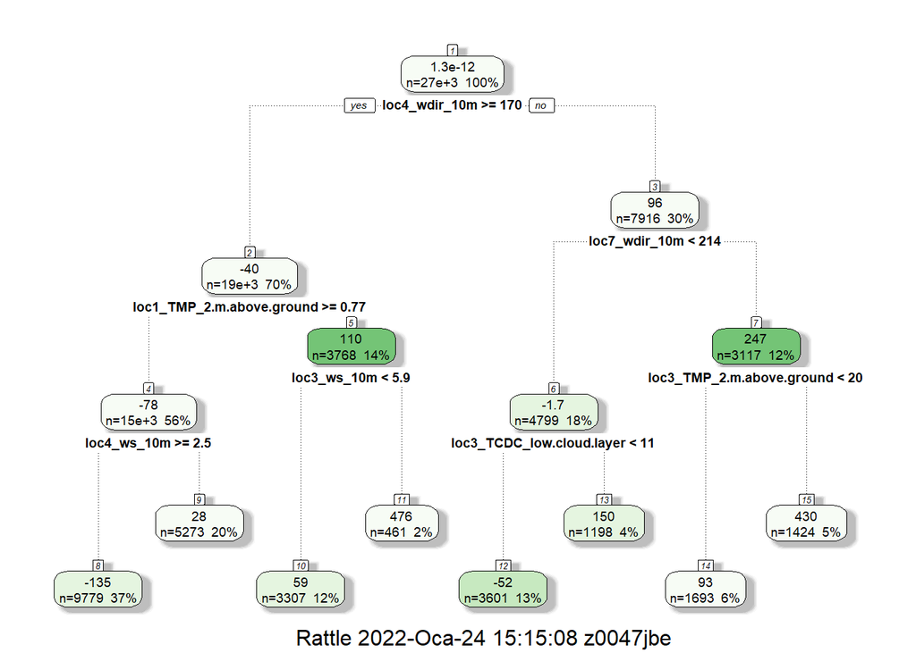

```r
tmp2[,residual:=actual-predicted]


fit_res_tree=rpart(residual~mon+
         loc1_DSWRF_surface+loc1_RH_2.m.above.ground+loc1_TCDC_low.cloud.layer+loc1_TMP_2.m.above.ground+loc1_ws_10m+
         loc2_DSWRF_surface+loc2_RH_2.m.above.ground+loc2_TCDC_low.cloud.layer+loc2_TMP_2.m.above.ground+loc2_wdir_10m+loc2_ws_10m+
         loc3_DSWRF_surface+loc3_RH_2.m.above.ground+loc3_TCDC_low.cloud.layer+loc3_TMP_2.m.above.ground+loc3_ws_10m+
         loc4_DSWRF_surface+loc4_RH_2.m.above.ground+loc4_TCDC_low.cloud.layer+loc4_wdir_10m+loc4_ws_10m+
         loc5_DSWRF_surface+loc5_RH_2.m.above.ground+loc5_TCDC_low.cloud.layer+loc5_wdir_10m+loc5_ws_10m+
         loc6_DSWRF_surface+loc6_RH_2.m.above.ground+loc6_TCDC_low.cloud.layer+loc6_wdir_10m+loc6_ws_10m+
         loc7_DSWRF_surface+loc7_RH_2.m.above.ground+loc7_TCDC_low.cloud.layer+loc7_wdir_10m,tmp2,
                   control=rpart.control(cp=0,maxdepth=3))

fancyRpartPlot(fit_res_tree)
```

```r
tmp2[,loc4wdir:=as.numeric(loc4_wdir_10m<170)]
tmp2[,loc7wdir:=as.numeric(loc7_wdir_10m>=214)]
tmp2[,loc3tmp2ag:=as.numeric(loc3_TMP_2.m.above.ground>=20)]

lm2_6=lm(net~trnd+w_day+mon+hour+prevday+prevweek+loc7tmp2ag:pv:loc7tmp2ag2+loc5tmp2ag:pd:workday+loc4tmp2ag:whour:loc3wdir+loc6tmp2ag:loc7ws:loc1wdir
         +loc4wdir:loc7wdir+loc3tmp2ag,
                 tmp2)
summary(lm2_6)
```

```
##
## Call:
## lm(formula = net ~ trnd + w_day + mon + hour + prevday + prevweek +
##     loc7tmp2ag:pv:loc7tmp2ag2 + loc5tmp2ag:pd:workday + loc4tmp2ag:whour:loc3wdir +
##     loc6tmp2ag:loc7ws:loc1wdir + loc4wdir:loc7wdir + loc3tmp2ag,
##     data = tmp2)
##
## Residuals:
##     Min      1Q  Median      3Q     Max
## -4953.7  -512.4    -4.2   497.3  5011.1
##
## Coefficients:
##                              Estimate Std. Error t value Pr(>|t|)
## (Intercept)                -3.130e+02  3.669e+01  -8.529  < 2e-16 ***
## trnd                        1.393e-02  7.361e-04  18.926  < 2e-16 ***
## w_dayCum                    5.717e+01  1.972e+01   2.899 0.003747 **
## w_dayÇar                    9.153e+01  1.972e+01   4.642 3.46e-06 ***
## w_dayPaz                   -1.656e+02  1.973e+01  -8.395  < 2e-16 ***
## w_dayPer                    1.385e+02  1.973e+01   7.023 2.23e-12 ***
## w_dayPzt                    2.039e+02  1.980e+01  10.297  < 2e-16 ***
## w_daySal                    1.395e+02  1.969e+01   7.084 1.44e-12 ***
## monAra                      7.352e+01  2.919e+01   2.518 0.011796 *
## monEki                      4.185e+01  2.753e+01   1.520 0.128547
## monEyl                     -1.057e+02  2.661e+01  -3.972 7.15e-05 ***
## monHaz                      6.205e+01  2.648e+01   2.343 0.019129 *
## monKas                      9.372e+01  2.893e+01   3.240 0.001198 **
## monMar                      5.335e+01  2.932e+01   1.820 0.068809 .
## monMay                     -3.284e+01  2.690e+01  -1.221 0.222211
## monNis                     -3.915e+01  2.884e+01  -1.358 0.174616
## monOca                      4.109e+01  2.889e+01   1.422 0.154965
## monŞub                      9.909e+01  3.028e+01   3.272 0.001069 **
## monTem                      6.401e+01  2.582e+01   2.479 0.013173 *
## hour1                       1.021e+02  3.645e+01   2.801 0.005100 **
## hour2                       7.011e+01  3.645e+01   1.924 0.054424 .
## hour3                       4.241e+01  3.646e+01   1.163 0.244814
## hour4                       1.175e+01  3.647e+01   0.322 0.747425
## hour5                       6.180e+00  3.650e+01   0.169 0.865561
## hour6                      -5.503e+01  3.652e+01  -1.507 0.131895
## hour7                      -4.210e+01  3.649e+01  -1.154 0.248666
## hour8                       6.958e+01  3.662e+01   1.900 0.057456 .
```

[output cut: 14 more lines]

```
## hour23                      1.195e+02  3.646e+01   3.278 0.001046 **
## prevday                     3.402e-01  5.611e-03  60.640  < 2e-16 ***
## prevweek                    5.942e-02  5.340e-03  11.127  < 2e-16 ***
## loc3tmp2ag                  2.026e+02  1.843e+01  10.992  < 2e-16 ***
## loc4wdir:loc7wdir           2.882e+02  1.711e+01  16.841  < 2e-16 ***
## loc7tmp2ag:pv:loc7tmp2ag2   3.512e+03  1.622e+02  21.655  < 2e-16 ***
## loc5tmp2ag:pd:workday       1.880e+03  8.040e+01  23.388  < 2e-16 ***
## loc4tmp2ag:whour:loc3wdir   1.183e+02  2.066e+01   5.724 1.05e-08 ***
## loc6tmp2ag:loc7ws:loc1wdir  1.453e+03  9.476e+01  15.334  < 2e-16 ***
## ---
## Signif. codes:  0 '***' 0.001 '**' 0.01 '*' 0.05 '.' 0.1 ' ' 1
##
## Residual standard error: 859.6 on 26686 degrees of freedom
## Multiple R-squared:  0.3325, Adjusted R-squared:  0.3312
## F-statistic: 271.2 on 49 and 26686 DF,  p-value: < 2.2e-16
```

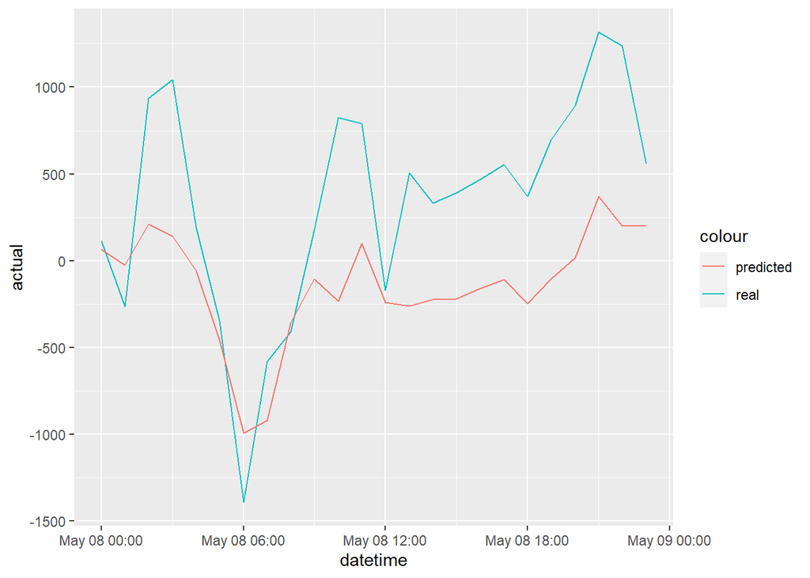

```r
tmp2[,predicted:=predict(lm2_6,tmp2)]
#head(tmp)
ggplot(tmp2[Date=='2019-05-08'] ,aes(x=datetime)) +
        geom_line(aes(y=actual,color='real')) +
        geom_line(aes(y=predicted,color='predicted'))
```

[figure not shown]

```r
tmp2[,residual:=actual-predicted]


fit_res_tree=rpart(residual~mon+
         loc1_DSWRF_surface+loc1_RH_2.m.above.ground+loc1_TCDC_low.cloud.layer+loc1_TMP_2.m.above.ground+loc1_ws_10m+
         loc2_DSWRF_surface+loc2_RH_2.m.above.ground+loc2_TCDC_low.cloud.layer+loc2_TMP_2.m.above.ground+loc2_wdir_10m+loc2_ws_10m+
         loc3_DSWRF_surface+loc3_RH_2.m.above.ground+loc3_TCDC_low.cloud.layer+loc3_ws_10m+
         loc4_DSWRF_surface+loc4_RH_2.m.above.ground+loc4_TCDC_low.cloud.layer+loc4_ws_10m+
         loc5_DSWRF_surface+loc5_RH_2.m.above.ground+loc5_TCDC_low.cloud.layer+loc5_wdir_10m+loc5_ws_10m+
         loc6_DSWRF_surface+loc6_RH_2.m.above.ground+loc6_TCDC_low.cloud.layer+loc6_wdir_10m+loc6_ws_10m+
         loc7_DSWRF_surface+loc7_RH_2.m.above.ground+loc7_TCDC_low.cloud.layer,tmp2,
                   control=rpart.control(cp=0,maxdepth=3))

fancyRpartPlot(fit_res_tree)
```

```r
tmp2[,loc3tcdc:=as.numeric(loc3_TCDC_low.cloud.layer>=8.6)]
tmp2[,mon1:=as.numeric(!mon %in% c('Haz','Tem','Ağu','Eyl','Eki'))]
tmp2[,loc4rh:=as.numeric(loc4_RH_2.m.above.ground<69)]

lm2_7=lm(net~trnd+w_day+mon+hour+prevday+prevweek+loc7tmp2ag:pv:loc7tmp2ag2+loc5tmp2ag:pd:workday+loc4tmp2ag:whour:loc3wdir+loc6tmp2ag:loc7ws:loc1wdir
         +loc4wdir:loc7wdir+loc3tmp2ag+loc3tcdc:mon1:loc4rh,
                 tmp2)
summary(lm2_7)
```

```
##
## Call:
## lm(formula = net ~ trnd + w_day + mon + hour + prevday + prevweek +
##     loc7tmp2ag:pv:loc7tmp2ag2 + loc5tmp2ag:pd:workday + loc4tmp2ag:whour:loc3wdir +
##     loc6tmp2ag:loc7ws:loc1wdir + loc4wdir:loc7wdir + loc3tmp2ag +
##     loc3tcdc:mon1:loc4rh, data = tmp2)
##
## Residuals:
##     Min      1Q  Median      3Q     Max
## -4937.4  -509.5    -4.1   492.3  4808.4
##
## Coefficients:
##                              Estimate Std. Error t value Pr(>|t|)
## (Intercept)                -3.260e+02  3.635e+01  -8.969  < 2e-16 ***
## trnd                        1.441e-02  7.294e-04  19.757  < 2e-16 ***
## w_dayCum                    4.431e+01  1.954e+01   2.268 0.023362 *
## w_dayÇar                    8.225e+01  1.953e+01   4.211 2.55e-05 ***
## w_dayPaz                   -1.662e+02  1.954e+01  -8.508  < 2e-16 ***
## w_dayPer                    1.263e+02  1.954e+01   6.463 1.04e-10 ***
## w_dayPzt                    2.058e+02  1.961e+01  10.492  < 2e-16 ***
## w_daySal                    1.393e+02  1.951e+01   7.141 9.51e-13 ***
## monAra                      6.318e+01  2.892e+01   2.185 0.028908 *
## monEki                      7.488e+01  2.731e+01   2.742 0.006110 **
## monEyl                     -8.969e+01  2.636e+01  -3.402 0.000669 ***
## monHaz                      7.800e+01  2.624e+01   2.973 0.002953 **
## monKas                      8.926e+01  2.865e+01   3.115 0.001840 **
## monMar                      6.269e-01  2.913e+01   0.022 0.982832
## monMay                     -6.772e+01  2.669e+01  -2.537 0.011184 *
## monNis                     -1.144e+02  2.876e+01  -3.980 6.92e-05 ***
## monOca                      3.766e+01  2.862e+01   1.316 0.188251
## monŞub                      8.106e+01  3.001e+01   2.702 0.006905 **
## monTem                      6.300e+01  2.557e+01   2.464 0.013759 *
## hour1                       1.050e+02  3.610e+01   2.908 0.003644 **
## hour2                       7.613e+01  3.610e+01   2.109 0.034966 *
## hour3                       5.293e+01  3.611e+01   1.466 0.142796
## hour4                       2.688e+01  3.613e+01   0.744 0.456906
## hour5                       2.292e+01  3.616e+01   0.634 0.526145
## hour6                      -3.977e+01  3.618e+01  -1.099 0.271601
## hour7                      -2.925e+01  3.615e+01  -0.809 0.418380
## hour8                       6.778e+01  3.627e+01   1.868 0.061713 .
```

[output cut: 15 more lines]

```
## prevday                     3.320e-01  5.569e-03  59.616  < 2e-16 ***
## prevweek                    6.078e-02  5.290e-03  11.491  < 2e-16 ***
## loc3tmp2ag                  2.664e+02  1.847e+01  14.425  < 2e-16 ***
## loc4wdir:loc7wdir           3.053e+02  1.697e+01  17.992  < 2e-16 ***
## loc7tmp2ag:pv:loc7tmp2ag2   3.535e+03  1.606e+02  22.004  < 2e-16 ***
## loc5tmp2ag:pd:workday       1.938e+03  7.967e+01  24.321  < 2e-16 ***
## loc4tmp2ag:whour:loc3wdir   9.141e+01  2.050e+01   4.459 8.27e-06 ***
## loc6tmp2ag:loc7ws:loc1wdir  1.470e+03  9.386e+01  15.658  < 2e-16 ***
## loc3tcdc:mon1:loc4rh        4.369e+02  1.918e+01  22.783  < 2e-16 ***
## ---
## Signif. codes:  0 '***' 0.001 '**' 0.01 '*' 0.05 '.' 0.1 ' ' 1
##
## Residual standard error: 851.4 on 26685 degrees of freedom
## Multiple R-squared:  0.3452, Adjusted R-squared:  0.344
## F-statistic: 281.3 on 50 and 26685 DF,  p-value: < 2.2e-16
```

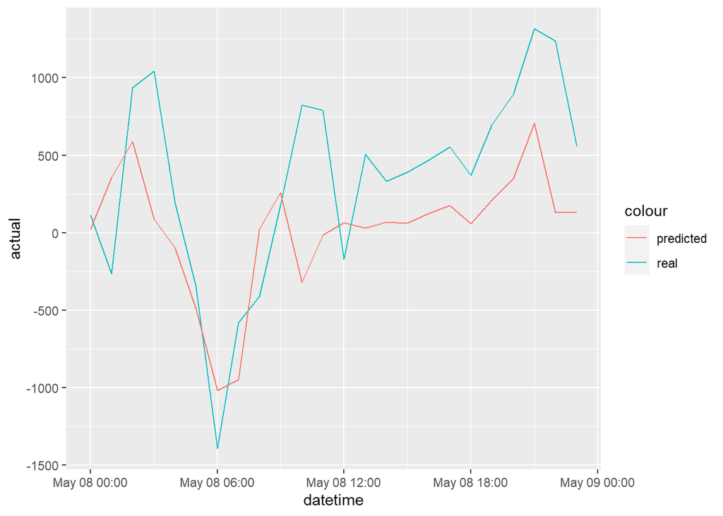

```r
tmp2[,predicted:=predict(lm2_7,tmp2)]
#head(tmp)
ggplot(tmp2[Date=='2019-05-08'] ,aes(x=datetime)) +
        geom_line(aes(y=actual,color='real')) +
        geom_line(aes(y=predicted,color='predicted'))
```

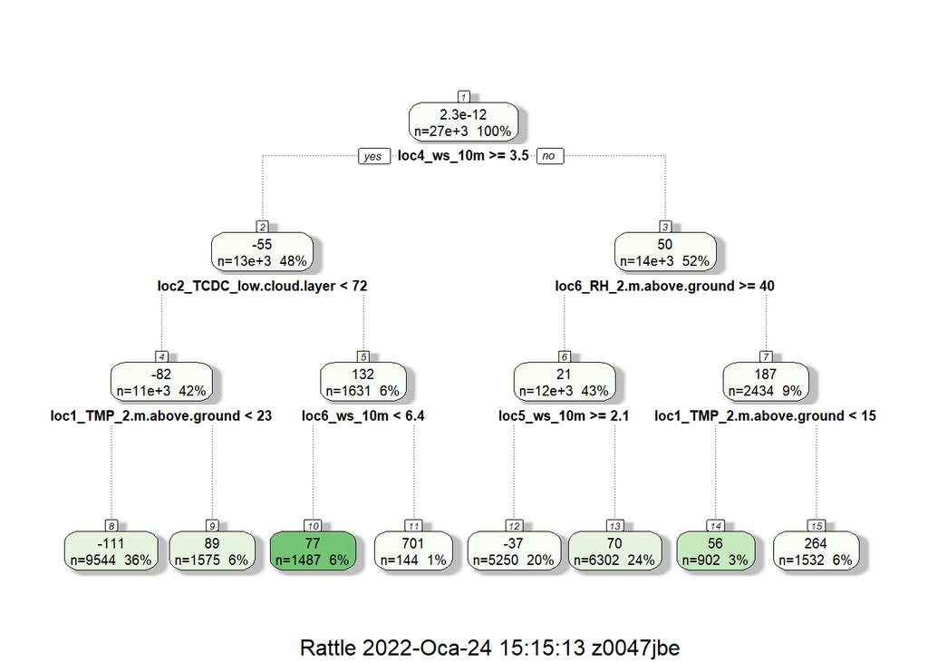

```r
tmp2[,residual:=actual-predicted]


fit_res_tree=rpart(residual~
         loc1_DSWRF_surface+loc1_RH_2.m.above.ground+loc1_TCDC_low.cloud.layer+loc1_TMP_2.m.above.ground+loc1_ws_10m+
         loc2_DSWRF_surface+loc2_RH_2.m.above.ground+loc2_TCDC_low.cloud.layer+loc2_TMP_2.m.above.ground+loc2_wdir_10m+loc2_ws_10m+
         loc3_DSWRF_surface+loc3_RH_2.m.above.ground+loc3_ws_10m+
         loc4_DSWRF_surface+loc4_TCDC_low.cloud.layer+loc4_ws_10m+
         loc5_DSWRF_surface+loc5_RH_2.m.above.ground+loc5_TCDC_low.cloud.layer+loc5_wdir_10m+loc5_ws_10m+
         loc6_DSWRF_surface+loc6_RH_2.m.above.ground+loc6_TCDC_low.cloud.layer+loc6_wdir_10m+loc6_ws_10m+
         loc7_DSWRF_surface+loc7_RH_2.m.above.ground+loc7_TCDC_low.cloud.layer,tmp2,
                   control=rpart.control(cp=0,maxdepth=3))

fancyRpartPlot(fit_res_tree)
```

```r
tmp2[,loc4ws:=as.numeric(loc4_ws_10m<3.5)]
tmp2[,loc6rh:=as.numeric(loc6_RH_2.m.above.ground<40)]
tmp2[,loc1tmp2ag:=as.numeric(loc1_TMP_2.m.above.ground>=15)]

lm2_8=lm(net~trnd+w_day+mon+hour+prevday+prevweek+loc7tmp2ag:pv:loc7tmp2ag2+loc5tmp2ag:pd:workday+loc4tmp2ag:whour:loc3wdir+loc6tmp2ag:loc7ws:loc1wdir
         +loc4wdir:loc7wdir+loc3tmp2ag+loc3tcdc:mon1:loc4rh+loc4ws:loc6rh:loc1tmp2ag,
                 tmp2)
summary(lm2_8)
```

```
##
## Call:
## lm(formula = net ~ trnd + w_day + mon + hour + prevday + prevweek +
##     loc7tmp2ag:pv:loc7tmp2ag2 + loc5tmp2ag:pd:workday + loc4tmp2ag:whour:loc3wdir +
##     loc6tmp2ag:loc7ws:loc1wdir + loc4wdir:loc7wdir + loc3tmp2ag +
##     loc3tcdc:mon1:loc4rh + loc4ws:loc6rh:loc1tmp2ag, data = tmp2)
##
## Residuals:
##     Min      1Q  Median      3Q     Max
## -4918.7  -507.0    -2.5   491.8  4657.5
##
## Coefficients:
##                              Estimate Std. Error t value Pr(>|t|)
## (Intercept)                -3.490e+02  3.627e+01  -9.621  < 2e-16 ***
## trnd                        1.436e-02  7.271e-04  19.746  < 2e-16 ***
## w_dayCum                    4.275e+01  1.948e+01   2.195 0.028198 *
## w_dayÇar                    7.887e+01  1.947e+01   4.051 5.12e-05 ***
## w_dayPaz                   -1.664e+02  1.948e+01  -8.544  < 2e-16 ***
## w_dayPer                    1.232e+02  1.948e+01   6.325 2.58e-10 ***
## w_dayPzt                    2.028e+02  1.955e+01  10.375  < 2e-16 ***
## w_daySal                    1.361e+02  1.944e+01   7.000 2.63e-12 ***
## monAra                      9.188e+01  2.891e+01   3.178 0.001484 **
## monEki                      7.816e+01  2.722e+01   2.871 0.004093 **
## monEyl                     -8.735e+01  2.628e+01  -3.324 0.000890 ***
## monHaz                      1.190e+02  2.634e+01   4.518 6.27e-06 ***
## monKas                      1.130e+02  2.862e+01   3.948 7.89e-05 ***
## monMar                      2.943e+01  2.912e+01   1.011 0.312174
## monMay                     -4.794e+01  2.665e+01  -1.799 0.072031 .
## monNis                     -8.841e+01  2.873e+01  -3.077 0.002093 **
## monOca                      6.628e+01  2.861e+01   2.317 0.020523 *
## monŞub                      1.096e+02  2.999e+01   3.655 0.000258 ***
## monTem                      9.065e+01  2.558e+01   3.544 0.000394 ***
## hour1                       1.058e+02  3.598e+01   2.940 0.003283 **
## hour2                       7.853e+01  3.599e+01   2.182 0.029110 *
## hour3                       5.572e+01  3.600e+01   1.548 0.121699
## hour4                       3.127e+01  3.602e+01   0.868 0.385237
## hour5                       2.569e+01  3.605e+01   0.713 0.475960
## hour6                      -3.589e+01  3.606e+01  -0.995 0.319636
## hour7                      -2.628e+01  3.603e+01  -0.729 0.465740
## hour8                       6.163e+01  3.616e+01   1.704 0.088321 .
```

[output cut: 16 more lines]

```
## prevweek                    6.293e-02  5.275e-03  11.929  < 2e-16 ***
## loc3tmp2ag                  2.266e+02  1.866e+01  12.145  < 2e-16 ***
## loc4wdir:loc7wdir           2.756e+02  1.706e+01  16.153  < 2e-16 ***
## loc7tmp2ag:pv:loc7tmp2ag2   3.563e+03  1.601e+02  22.249  < 2e-16 ***
## loc5tmp2ag:pd:workday       1.971e+03  7.946e+01  24.800  < 2e-16 ***
## loc4tmp2ag:whour:loc3wdir   8.694e+01  2.044e+01   4.254 2.11e-05 ***
## loc6tmp2ag:loc7ws:loc1wdir  1.413e+03  9.366e+01  15.090  < 2e-16 ***
## loc3tcdc:mon1:loc4rh        4.387e+02  1.912e+01  22.952  < 2e-16 ***
## loc4ws:loc6rh:loc1tmp2ag    3.260e+02  2.484e+01  13.124  < 2e-16 ***
## ---
## Signif. codes:  0 '***' 0.001 '**' 0.01 '*' 0.05 '.' 0.1 ' ' 1
##
## Residual standard error: 848.7 on 26684 degrees of freedom
## Multiple R-squared:  0.3494, Adjusted R-squared:  0.3481
## F-statistic:   281 on 51 and 26684 DF,  p-value: < 2.2e-16
```

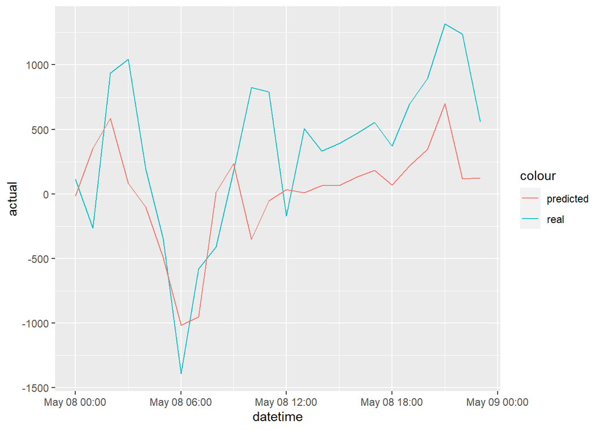

```r
tmp2[,predicted:=predict(lm2_8,tmp2)]
#head(tmp)
ggplot(tmp2[Date=='2019-05-08'] ,aes(x=datetime)) +
        geom_line(aes(y=actual,color='real')) +
        geom_line(aes(y=predicted,color='predicted'))
```

[figure not shown]

```r
tmp2[,residual:=actual-predicted]


fit_res_tree=rpart(residual~
         loc1_DSWRF_surface+loc1_RH_2.m.above.ground+loc1_TCDC_low.cloud.layer+loc1_ws_10m+
         loc2_DSWRF_surface+loc2_RH_2.m.above.ground+loc2_TCDC_low.cloud.layer+loc2_TMP_2.m.above.ground+loc2_wdir_10m+loc2_ws_10m+
         loc3_DSWRF_surface+loc3_RH_2.m.above.ground+loc3_ws_10m+
         loc4_DSWRF_surface+loc4_TCDC_low.cloud.layer+
         loc5_DSWRF_surface+loc5_RH_2.m.above.ground+loc5_TCDC_low.cloud.layer+loc5_wdir_10m+loc5_ws_10m+
         loc6_DSWRF_surface+loc6_TCDC_low.cloud.layer+loc6_wdir_10m+loc6_ws_10m+
         loc7_DSWRF_surface+loc7_RH_2.m.above.ground+loc7_TCDC_low.cloud.layer,tmp2,
                   control=rpart.control(cp=0,maxdepth=3))

fancyRpartPlot(fit_res_tree)
```

```r
tmp2[,loc5ws:=as.numeric(loc5_ws_10m<2.4)]
tmp2[,loc2tmp2ag:=as.numeric(loc2_TMP_2.m.above.ground<2.3)]
tmp2[,loc7rh2:=as.numeric(loc7_RH_2.m.above.ground<63)]

lm2_9=lm(net~trnd+w_day+mon+hour+prevday+prevweek+loc7tmp2ag:pv:loc7tmp2ag2+loc5tmp2ag:pd:workday+loc4tmp2ag:whour:loc3wdir+loc6tmp2ag:loc7ws:loc1wdir
         +loc4wdir:loc7wdir+loc3tmp2ag+loc3tcdc:mon1:loc4rh+loc4ws:loc6rh:loc1tmp2ag+loc5ws:loc2tmp2ag:loc7rh2,
                 tmp2)
summary(lm2_9)
```

```
##
## Call:
## lm(formula = net ~ trnd + w_day + mon + hour + prevday + prevweek +
##     loc7tmp2ag:pv:loc7tmp2ag2 + loc5tmp2ag:pd:workday + loc4tmp2ag:whour:loc3wdir +
##     loc6tmp2ag:loc7ws:loc1wdir + loc4wdir:loc7wdir + loc3tmp2ag +
##     loc3tcdc:mon1:loc4rh + loc4ws:loc6rh:loc1tmp2ag + loc5ws:loc2tmp2ag:loc7rh2,
##     data = tmp2)
##
## Residuals:
##     Min      1Q  Median      3Q     Max
## -4921.2  -506.7    -2.0   491.8  4662.1
##
## Coefficients:
##                              Estimate Std. Error t value Pr(>|t|)
## (Intercept)                -3.486e+02  3.625e+01  -9.617  < 2e-16 ***
## trnd                        1.420e-02  7.270e-04  19.528  < 2e-16 ***
## w_dayCum                    4.311e+01  1.946e+01   2.215 0.026775 *
## w_dayÇar                    8.040e+01  1.946e+01   4.132 3.61e-05 ***
## w_dayPaz                   -1.644e+02  1.946e+01  -8.449  < 2e-16 ***
## w_dayPer                    1.255e+02  1.947e+01   6.446 1.17e-10 ***
## w_dayPzt                    2.025e+02  1.954e+01  10.366  < 2e-16 ***
## w_daySal                    1.382e+02  1.943e+01   7.112 1.17e-12 ***
## monAra                      8.896e+01  2.889e+01   3.079 0.002078 **
## monEki                      7.824e+01  2.720e+01   2.876 0.004030 **
## monEyl                     -8.737e+01  2.626e+01  -3.327 0.000880 ***
## monHaz                      1.187e+02  2.632e+01   4.508 6.56e-06 ***
## monKas                      1.137e+02  2.860e+01   3.974 7.08e-05 ***
## monMar                      3.030e+01  2.910e+01   1.041 0.297748
## monMay                     -4.861e+01  2.663e+01  -1.825 0.067959 .
## monNis                     -8.866e+01  2.871e+01  -3.088 0.002018 **
## monOca                      6.128e+01  2.860e+01   2.143 0.032150 *
## monŞub                      1.091e+02  2.997e+01   3.642 0.000271 ***
## monTem                      9.054e+01  2.556e+01   3.542 0.000397 ***
## hour1                       1.051e+02  3.596e+01   2.924 0.003461 **
## hour2                       7.938e+01  3.596e+01   2.207 0.027288 *
## hour3                       5.670e+01  3.597e+01   1.576 0.114999
## hour4                       3.230e+01  3.599e+01   0.897 0.369499
## hour5                       2.684e+01  3.602e+01   0.745 0.456165
## hour6                      -3.319e+01  3.604e+01  -0.921 0.357027
## hour7                      -2.424e+01  3.601e+01  -0.673 0.500805
```

[output cut: 18 more lines]

```
## loc3tmp2ag                  2.264e+02  1.865e+01  12.142  < 2e-16 ***
## loc4wdir:loc7wdir           2.755e+02  1.705e+01  16.160  < 2e-16 ***
## loc7tmp2ag:pv:loc7tmp2ag2   3.564e+03  1.600e+02  22.271  < 2e-16 ***
## loc5tmp2ag:pd:workday       1.971e+03  7.940e+01  24.824  < 2e-16 ***
## loc4tmp2ag:whour:loc3wdir   7.721e+01  2.048e+01   3.770 0.000164 ***
## loc6tmp2ag:loc7ws:loc1wdir  1.414e+03  9.359e+01  15.109  < 2e-16 ***
## loc3tcdc:mon1:loc4rh        4.401e+02  1.910e+01  23.036  < 2e-16 ***
## loc4ws:loc6rh:loc1tmp2ag    3.261e+02  2.482e+01  13.136  < 2e-16 ***
## loc5ws:loc2tmp2ag:loc7rh2   8.404e+02  1.336e+02   6.292 3.17e-10 ***
## ---
## Signif. codes:  0 '***' 0.001 '**' 0.01 '*' 0.05 '.' 0.1 ' ' 1
##
## Residual standard error: 848.1 on 26683 degrees of freedom
## Multiple R-squared:  0.3504, Adjusted R-squared:  0.3491
## F-statistic: 276.7 on 52 and 26683 DF,  p-value: < 2.2e-16
```

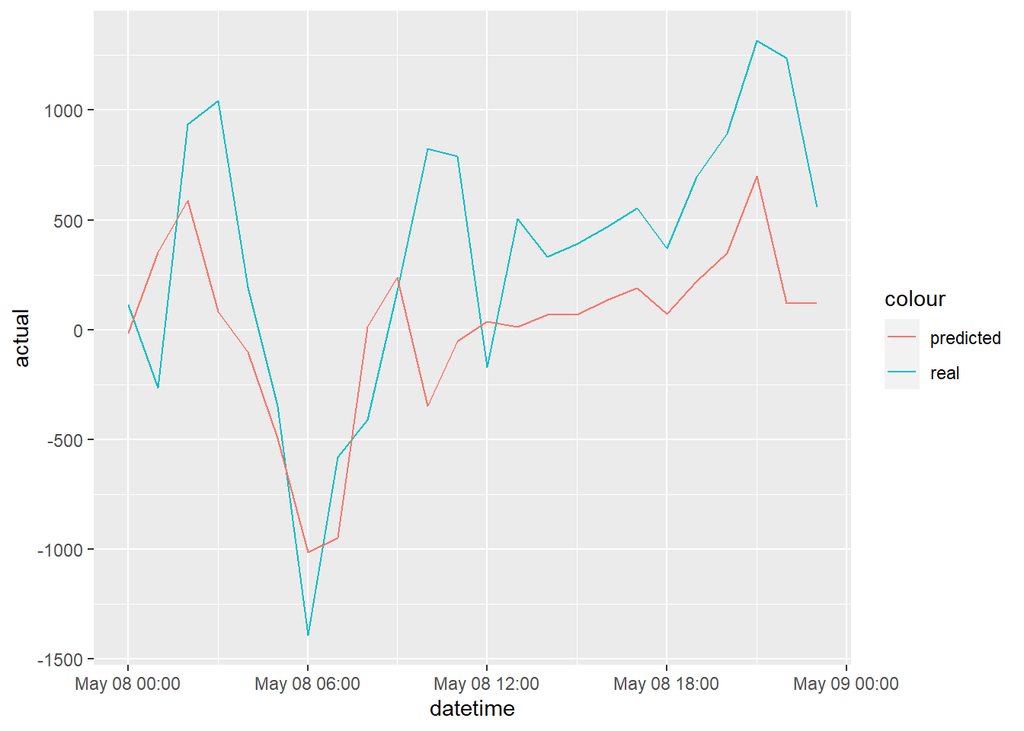

```r
tmp2[,predicted:=predict(lm2_9,tmp2)]
#head(tmp)
ggplot(tmp2[Date=='2019-05-08'] ,aes(x=datetime)) +
        geom_line(aes(y=actual,color='real')) +
        geom_line(aes(y=predicted,color='predicted'))
```

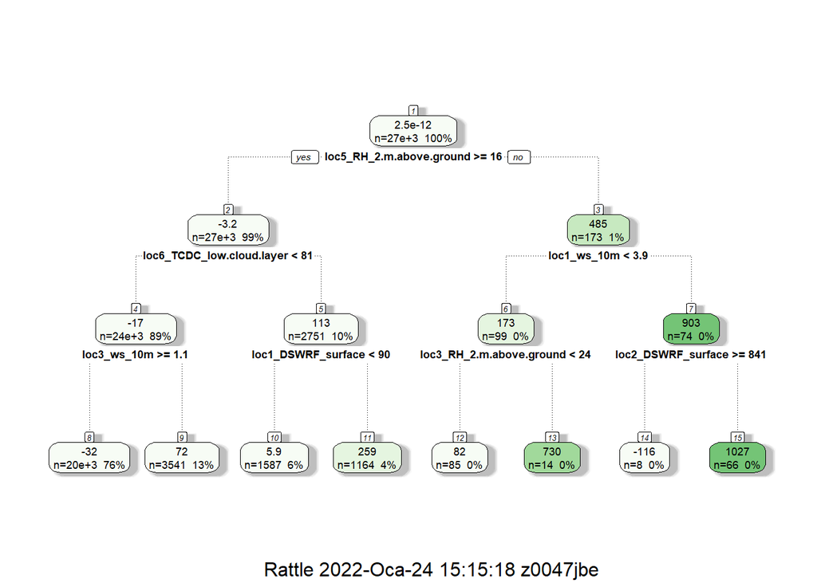

```r
tmp2[,residual:=actual-predicted]


fit_res_tree=rpart(residual~
         loc1_DSWRF_surface+loc1_RH_2.m.above.ground+loc1_TCDC_low.cloud.layer+loc1_ws_10m+
         loc2_DSWRF_surface+loc2_RH_2.m.above.ground+loc2_TCDC_low.cloud.layer+loc2_wdir_10m+loc2_ws_10m+
         loc3_DSWRF_surface+loc3_RH_2.m.above.ground+loc3_ws_10m+
         loc4_DSWRF_surface+loc4_TCDC_low.cloud.layer+
         loc5_DSWRF_surface+loc5_RH_2.m.above.ground+loc5_TCDC_low.cloud.layer+loc5_wdir_10m+
         loc6_DSWRF_surface+loc6_TCDC_low.cloud.layer+loc6_wdir_10m+loc6_ws_10m+
         loc7_DSWRF_surface+loc7_TCDC_low.cloud.layer,tmp2,
                   control=rpart.control(cp=0,maxdepth=3))

fancyRpartPlot(fit_res_tree)
```

```r
tmp2[,loc5rh:=as.numeric(loc5_RH_2.m.above.ground<16)]
tmp2[,loc1ws:=as.numeric(loc1_ws_10m>=3.9)]
tmp2[,loc2dswrf:=as.numeric(loc2_DSWRF_surface<841)]

lm2_10=lm(net~trnd+w_day+mon+hour+prevday+prevweek+loc7tmp2ag:pv:loc7tmp2ag2+loc5tmp2ag:pd:workday+loc4tmp2ag:whour:loc3wdir+loc6tmp2ag:loc7ws:loc1wdir
         +loc4wdir:loc7wdir+loc3tmp2ag+loc3tcdc:mon1:loc4rh+loc4ws:loc6rh:loc1tmp2ag+loc5ws:loc2tmp2ag:loc7rh2+loc5rh:loc1ws:loc2dswrf,
                 tmp2)
summary(lm2_10)
```

```
##
## Call:
## lm(formula = net ~ trnd + w_day + mon + hour + prevday + prevweek +
##     loc7tmp2ag:pv:loc7tmp2ag2 + loc5tmp2ag:pd:workday + loc4tmp2ag:whour:loc3wdir +
##     loc6tmp2ag:loc7ws:loc1wdir + loc4wdir:loc7wdir + loc3tmp2ag +
##     loc3tcdc:mon1:loc4rh + loc4ws:loc6rh:loc1tmp2ag + loc5ws:loc2tmp2ag:loc7rh2 +
##     loc5rh:loc1ws:loc2dswrf, data = tmp2)
##
## Residuals:
##     Min      1Q  Median      3Q     Max
## -4914.7  -506.1    -1.8   491.1  4666.1
##
## Coefficients:
##                              Estimate Std. Error t value Pr(>|t|)
## (Intercept)                -3.613e+02  3.620e+01  -9.982  < 2e-16 ***
## trnd                        1.424e-02  7.256e-04  19.624  < 2e-16 ***
## w_dayCum                    4.336e+01  1.943e+01   2.232 0.025621 *
## w_dayÇar                    8.046e+01  1.942e+01   4.143 3.45e-05 ***
## w_dayPaz                   -1.643e+02  1.943e+01  -8.458  < 2e-16 ***
## w_dayPer                    1.243e+02  1.944e+01   6.395 1.63e-10 ***
## w_dayPzt                    2.011e+02  1.950e+01  10.312  < 2e-16 ***
## w_daySal                    1.364e+02  1.940e+01   7.032 2.09e-12 ***
## monAra                      1.036e+02  2.887e+01   3.587 0.000335 ***
## monEki                      9.138e+01  2.718e+01   3.362 0.000776 ***
## monEyl                     -7.743e+01  2.623e+01  -2.952 0.003163 **
## monHaz                      1.359e+02  2.633e+01   5.163 2.45e-07 ***
## monKas                      1.278e+02  2.858e+01   4.472 7.77e-06 ***
## monMar                      4.467e+01  2.908e+01   1.536 0.124489
## monMay                     -3.440e+01  2.662e+01  -1.293 0.196183
## monNis                     -7.479e+01  2.869e+01  -2.607 0.009149 **
## monOca                      7.599e+01  2.858e+01   2.658 0.007856 **
## monŞub                      1.239e+02  2.995e+01   4.136 3.54e-05 ***
## monTem                      1.099e+02  2.558e+01   4.297 1.74e-05 ***
## hour1                       1.053e+02  3.589e+01   2.934 0.003347 **
## hour2                       7.941e+01  3.589e+01   2.212 0.026949 *
## hour3                       5.664e+01  3.591e+01   1.577 0.114708
## hour4                       3.217e+01  3.592e+01   0.896 0.370471
## hour5                       2.663e+01  3.595e+01   0.741 0.458915
## hour6                      -3.355e+01  3.597e+01  -0.933 0.351030
## hour7                      -2.439e+01  3.594e+01  -0.678 0.497488
```

[output cut: 19 more lines]

```
## loc4wdir:loc7wdir           2.758e+02  1.702e+01  16.204  < 2e-16 ***
## loc7tmp2ag:pv:loc7tmp2ag2   3.398e+03  1.606e+02  21.159  < 2e-16 ***
## loc5tmp2ag:pd:workday       1.815e+03  8.076e+01  22.477  < 2e-16 ***
## loc4tmp2ag:whour:loc3wdir   7.523e+01  2.044e+01   3.680 0.000234 ***
## loc6tmp2ag:loc7ws:loc1wdir  1.432e+03  9.343e+01  15.326  < 2e-16 ***
## loc3tcdc:mon1:loc4rh        4.421e+02  1.907e+01  23.184  < 2e-16 ***
## loc4ws:loc6rh:loc1tmp2ag    3.347e+02  2.479e+01  13.501  < 2e-16 ***
## loc5ws:loc2tmp2ag:loc7rh2   8.401e+02  1.333e+02   6.302 2.98e-10 ***
## loc5rh:loc1ws:loc2dswrf     1.116e+03  1.110e+02  10.052  < 2e-16 ***
## ---
## Signif. codes:  0 '***' 0.001 '**' 0.01 '*' 0.05 '.' 0.1 ' ' 1
##
## Residual standard error: 846.5 on 26682 degrees of freedom
## Multiple R-squared:  0.3528, Adjusted R-squared:  0.3515
## F-statistic: 274.4 on 53 and 26682 DF,  p-value: < 2.2e-16
```

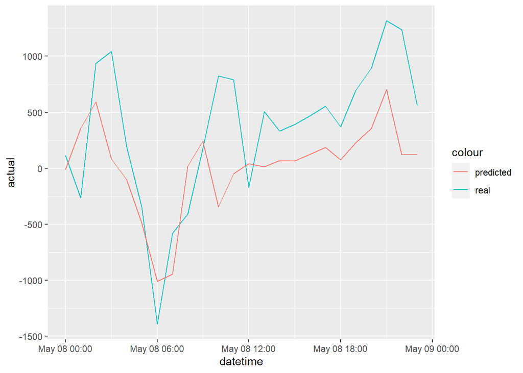

```r
tmp2[,predicted:=predict(lm2_10,tmp2)]
#head(tmp)
ggplot(tmp2[Date=='2019-05-08'] ,aes(x=datetime)) +
        geom_line(aes(y=actual,color='real')) +
        geom_line(aes(y=predicted,color='predicted'))
```

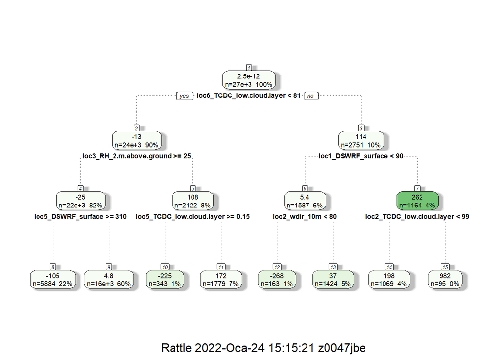

```r
tmp2[,residual:=actual-predicted]


fit_res_tree=rpart(residual~
         loc1_DSWRF_surface+loc1_RH_2.m.above.ground+loc1_TCDC_low.cloud.layer+
         loc2_RH_2.m.above.ground+loc2_TCDC_low.cloud.layer+loc2_wdir_10m+loc2_ws_10m+
         loc3_DSWRF_surface+loc3_RH_2.m.above.ground+loc3_ws_10m+
         loc4_DSWRF_surface+loc4_TCDC_low.cloud.layer+
         loc5_DSWRF_surface+loc5_TCDC_low.cloud.layer+loc5_wdir_10m+
         loc6_DSWRF_surface+loc6_TCDC_low.cloud.layer+loc6_wdir_10m+loc6_ws_10m+
         loc7_DSWRF_surface+loc7_TCDC_low.cloud.layer,tmp2,
                   control=rpart.control(cp=0,maxdepth=3))

fancyRpartPlot(fit_res_tree)
```

```r
tmp2[,loc6tcdc:=as.numeric(loc6_TCDC_low.cloud.layer>=84)]
tmp2[,loc1dswrf:=as.numeric(loc1_DSWRF_surface>=90)]
tmp2[,loc2rh2:=as.numeric(loc2_RH_2.m.above.ground>=91)]

lm2_11=lm(net~trnd+w_day+mon+hour+prevday+prevweek+loc7tmp2ag:pv:loc7tmp2ag2+loc5tmp2ag:pd:workday+loc4tmp2ag:whour:loc3wdir+loc6tmp2ag:loc7ws:loc1wdir
         +loc4wdir:loc7wdir+loc3tmp2ag+loc3tcdc:mon1:loc4rh+loc4ws:loc6rh:loc1tmp2ag+loc5ws:loc2tmp2ag:loc7rh2+loc5rh:loc1ws:loc2dswrf
         +loc6tcdc:loc1dswrf:loc2rh2,
                 tmp2)
summary(lm2_11)
```

```
##
## Call:
## lm(formula = net ~ trnd + w_day + mon + hour + prevday + prevweek +
##     loc7tmp2ag:pv:loc7tmp2ag2 + loc5tmp2ag:pd:workday + loc4tmp2ag:whour:loc3wdir +
##     loc6tmp2ag:loc7ws:loc1wdir + loc4wdir:loc7wdir + loc3tmp2ag +
##     loc3tcdc:mon1:loc4rh + loc4ws:loc6rh:loc1tmp2ag + loc5ws:loc2tmp2ag:loc7rh2 +
##     loc5rh:loc1ws:loc2dswrf + loc6tcdc:loc1dswrf:loc2rh2, data = tmp2)
##
## Residuals:
##     Min      1Q  Median      3Q     Max
## -4913.1  -505.5    -1.1   491.4  4582.7
##
## Coefficients:
##                              Estimate Std. Error t value Pr(>|t|)
## (Intercept)                -3.606e+02  3.613e+01  -9.982  < 2e-16 ***
## trnd                        1.424e-02  7.241e-04  19.666  < 2e-16 ***
## w_dayCum                    4.453e+01  1.939e+01   2.297 0.021622 *
## w_dayÇar                    7.985e+01  1.938e+01   4.120 3.80e-05 ***
## w_dayPaz                   -1.649e+02  1.939e+01  -8.504  < 2e-16 ***
## w_dayPer                    1.251e+02  1.940e+01   6.448 1.15e-10 ***
## w_dayPzt                    1.969e+02  1.946e+01  10.115  < 2e-16 ***
## w_daySal                    1.369e+02  1.936e+01   7.069 1.60e-12 ***
## monAra                      9.554e+01  2.882e+01   3.315 0.000919 ***
## monEki                      9.210e+01  2.713e+01   3.395 0.000687 ***
## monEyl                     -7.715e+01  2.618e+01  -2.947 0.003209 **
## monHaz                      1.362e+02  2.627e+01   5.183 2.20e-07 ***
## monKas                      1.301e+02  2.852e+01   4.560 5.15e-06 ***
## monMar                      4.560e+01  2.902e+01   1.571 0.116134
## monMay                     -3.286e+01  2.656e+01  -1.237 0.216030
## monNis                     -7.229e+01  2.863e+01  -2.525 0.011590 *
## monOca                      7.553e+01  2.853e+01   2.648 0.008106 **
## monŞub                      1.206e+02  2.989e+01   4.036 5.45e-05 ***
## monTem                      1.098e+02  2.553e+01   4.301 1.70e-05 ***
## hour1                       1.055e+02  3.582e+01   2.946 0.003223 **
## hour2                       7.959e+01  3.582e+01   2.222 0.026299 *
## hour3                       5.674e+01  3.583e+01   1.584 0.113307
## hour4                       3.217e+01  3.585e+01   0.897 0.369523
## hour5                       2.665e+01  3.588e+01   0.743 0.457627
## hour6                      -3.359e+01  3.590e+01  -0.936 0.349498
## hour7                      -2.446e+01  3.587e+01  -0.682 0.495239
```

[output cut: 20 more lines]

```
## loc7tmp2ag:pv:loc7tmp2ag2   3.400e+03  1.602e+02  21.219  < 2e-16 ***
## loc5tmp2ag:pd:workday       1.817e+03  8.059e+01  22.545  < 2e-16 ***
## loc4tmp2ag:whour:loc3wdir   7.577e+01  2.040e+01   3.714 0.000205 ***
## loc6tmp2ag:loc7ws:loc1wdir  1.434e+03  9.324e+01  15.377  < 2e-16 ***
## loc3tcdc:mon1:loc4rh        4.330e+02  1.905e+01  22.731  < 2e-16 ***
## loc4ws:loc6rh:loc1tmp2ag    3.345e+02  2.474e+01  13.520  < 2e-16 ***
## loc5ws:loc2tmp2ag:loc7rh2   8.439e+02  1.330e+02   6.343 2.28e-10 ***
## loc5rh:loc1ws:loc2dswrf     1.117e+03  1.108e+02  10.084  < 2e-16 ***
## loc6tcdc:loc1dswrf:loc2rh2  1.658e+03  1.576e+02  10.522  < 2e-16 ***
## ---
## Signif. codes:  0 '***' 0.001 '**' 0.01 '*' 0.05 '.' 0.1 ' ' 1
##
## Residual standard error: 844.7 on 26681 degrees of freedom
## Multiple R-squared:  0.3555, Adjusted R-squared:  0.3542
## F-statistic: 272.5 on 54 and 26681 DF,  p-value: < 2.2e-16
```

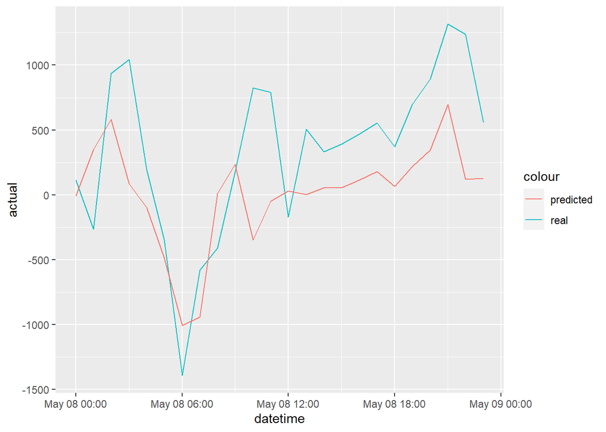

```r
tmp2[,predicted:=predict(lm2_11,tmp2)]
#head(tmp)
ggplot(tmp2[Date=='2019-05-08'] ,aes(x=datetime)) +
        geom_line(aes(y=actual,color='real')) +
        geom_line(aes(y=predicted,color='predicted'))
```

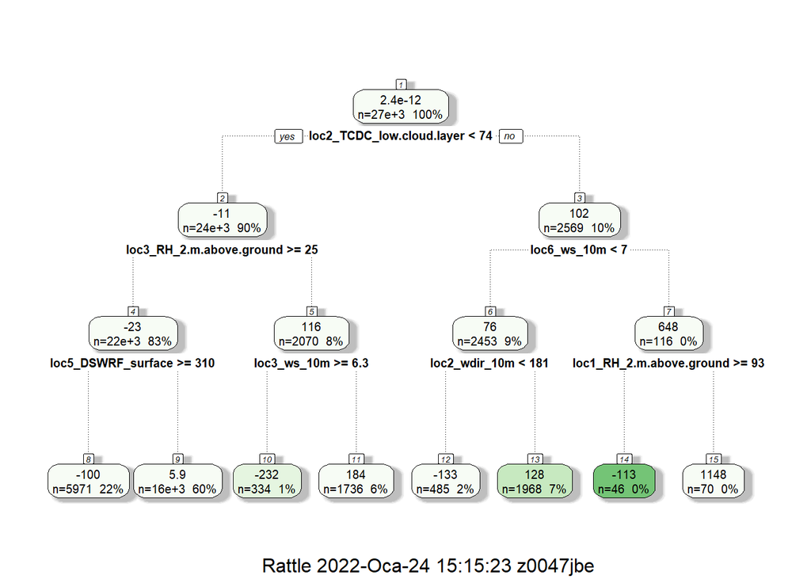

```r
tmp2[,residual:=actual-predicted]


fit_res_tree=rpart(residual~
         loc1_RH_2.m.above.ground+loc1_TCDC_low.cloud.layer+
         loc2_TCDC_low.cloud.layer+loc2_wdir_10m+loc2_ws_10m+
         loc3_DSWRF_surface+loc3_RH_2.m.above.ground+loc3_ws_10m+
         loc4_DSWRF_surface+loc4_TCDC_low.cloud.layer+
         loc5_DSWRF_surface+loc5_TCDC_low.cloud.layer+loc5_wdir_10m+
         loc6_DSWRF_surface+loc6_wdir_10m+loc6_ws_10m+
         loc7_DSWRF_surface+loc7_TCDC_low.cloud.layer,tmp2,
                   control=rpart.control(cp=0,maxdepth=3))

fancyRpartPlot(fit_res_tree)
```

```r
tmp2[,loc3ws:=as.numeric(loc3_ws_10m<1.1)]
tmp2[,loc1tcdc:=as.numeric(loc1_TCDC_low.cloud.layer>=63)]
tmp2[,loc5wdir:=as.numeric(loc5_wdir_10m<69)]

lm2_12=lm(net~trnd+w_day+mon+hour+prevday+prevweek+loc7tmp2ag:pv:loc7tmp2ag2+loc5tmp2ag:pd:workday+loc4tmp2ag:whour:loc3wdir+loc6tmp2ag:loc7ws:loc1wdir
         +loc4wdir:loc7wdir+loc3tmp2ag+loc3tcdc:mon1:loc4rh+loc4ws:loc6rh:loc1tmp2ag+loc5ws:loc2tmp2ag:loc7rh2+loc5rh:loc1ws:loc2dswrf
         +loc6tcdc:loc1dswrf:loc2rh2+loc3ws:loc1tcdc:loc5wdir,
                 tmp2)
summary(lm2_12)
```

```
##
## Call:
## lm(formula = net ~ trnd + w_day + mon + hour + prevday + prevweek +
##     loc7tmp2ag:pv:loc7tmp2ag2 + loc5tmp2ag:pd:workday + loc4tmp2ag:whour:loc3wdir +
##     loc6tmp2ag:loc7ws:loc1wdir + loc4wdir:loc7wdir + loc3tmp2ag +
##     loc3tcdc:mon1:loc4rh + loc4ws:loc6rh:loc1tmp2ag + loc5ws:loc2tmp2ag:loc7rh2 +
##     loc5rh:loc1ws:loc2dswrf + loc6tcdc:loc1dswrf:loc2rh2 + loc3ws:loc1tcdc:loc5wdir,
##     data = tmp2)
##
## Residuals:
##     Min      1Q  Median      3Q     Max
## -4917.4  -505.7    -0.5   492.6  4587.9
##
## Coefficients:
##                              Estimate Std. Error t value Pr(>|t|)
## (Intercept)                -3.592e+02  3.608e+01  -9.956  < 2e-16 ***
## trnd                        1.409e-02  7.234e-04  19.480  < 2e-16 ***
## w_dayCum                    4.443e+01  1.936e+01   2.295 0.021756 *
## w_dayÇar                    8.055e+01  1.936e+01   4.161 3.17e-05 ***
## w_dayPaz                   -1.641e+02  1.936e+01  -8.476  < 2e-16 ***
## w_dayPer                    1.232e+02  1.937e+01   6.358 2.08e-10 ***
## w_dayPzt                    1.956e+02  1.944e+01  10.064  < 2e-16 ***
## w_daySal                    1.377e+02  1.933e+01   7.124 1.07e-12 ***
## monAra                      9.177e+01  2.879e+01   3.188 0.001436 **
## monEki                      9.250e+01  2.709e+01   3.414 0.000640 ***
## monEyl                     -7.695e+01  2.614e+01  -2.943 0.003250 **
## monHaz                      1.361e+02  2.624e+01   5.187 2.16e-07 ***
## monKas                      1.290e+02  2.848e+01   4.528 5.97e-06 ***
## monMar                      4.181e+01  2.899e+01   1.442 0.149196
## monMay                     -3.336e+01  2.653e+01  -1.258 0.208551
## monNis                     -7.329e+01  2.860e+01  -2.563 0.010385 *
## monOca                      6.925e+01  2.850e+01   2.430 0.015105 *
## monŞub                      1.194e+02  2.985e+01   4.000 6.34e-05 ***
## monTem                      1.098e+02  2.550e+01   4.306 1.67e-05 ***
## hour1                       1.065e+02  3.577e+01   2.978 0.002907 **
## hour2                       7.852e+01  3.577e+01   2.195 0.028169 *
## hour3                       5.878e+01  3.579e+01   1.642 0.100499
## hour4                       3.316e+01  3.580e+01   0.926 0.354324
## hour5                       2.761e+01  3.583e+01   0.771 0.440913
## hour6                      -3.155e+01  3.585e+01  -0.880 0.378814
```

[output cut: 22 more lines]

```
## loc5tmp2ag:pd:workday       1.818e+03  8.048e+01  22.587  < 2e-16 ***
## loc4tmp2ag:whour:loc3wdir   7.682e+01  2.038e+01   3.770 0.000164 ***
## loc6tmp2ag:loc7ws:loc1wdir  1.434e+03  9.311e+01  15.402  < 2e-16 ***
## loc3tcdc:mon1:loc4rh        4.320e+02  1.902e+01  22.707  < 2e-16 ***
## loc4ws:loc6rh:loc1tmp2ag    3.349e+02  2.471e+01  13.554  < 2e-16 ***
## loc5ws:loc2tmp2ag:loc7rh2   8.492e+02  1.329e+02   6.392 1.66e-10 ***
## loc5rh:loc1ws:loc2dswrf     1.117e+03  1.107e+02  10.095  < 2e-16 ***
## loc6tcdc:loc1dswrf:loc2rh2  1.502e+03  1.584e+02   9.483  < 2e-16 ***
## loc3ws:loc1tcdc:loc5wdir    1.158e+03  1.364e+02   8.491  < 2e-16 ***
## ---
## Signif. codes:  0 '***' 0.001 '**' 0.01 '*' 0.05 '.' 0.1 ' ' 1
##
## Residual standard error: 843.6 on 26680 degrees of freedom
## Multiple R-squared:  0.3572, Adjusted R-squared:  0.3559
## F-statistic: 269.6 on 55 and 26680 DF,  p-value: < 2.2e-16
```

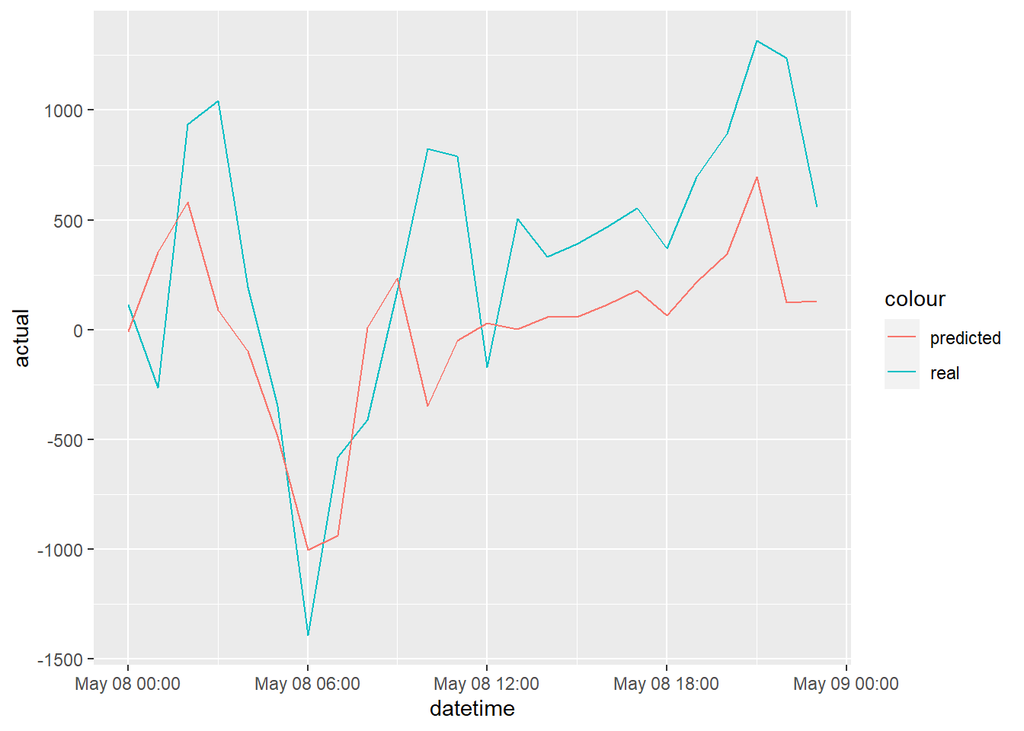

```r
tmp2[,predicted:=predict(lm2_12,tmp2)]
#head(tmp)
ggplot(tmp2[Date=='2019-05-08'] ,aes(x=datetime)) +
        geom_line(aes(y=actual,color='real')) +
        geom_line(aes(y=predicted,color='predicted'))
```

[figure not shown]

```r
tmp2[,residual:=actual-predicted]


fit_res_tree=rpart(residual~
         loc1_RH_2.m.above.ground+
         loc2_TCDC_low.cloud.layer+loc2_wdir_10m+loc2_ws_10m+
         loc3_DSWRF_surface+loc3_RH_2.m.above.ground+
         loc4_DSWRF_surface+loc4_TCDC_low.cloud.layer+
         loc5_DSWRF_surface+loc5_TCDC_low.cloud.layer+
         loc6_DSWRF_surface+loc6_wdir_10m+loc6_ws_10m+
         loc7_DSWRF_surface+loc7_TCDC_low.cloud.layer,tmp2,
                   control=rpart.control(cp=0,maxdepth=3))

fancyRpartPlot(fit_res_tree)
```

```r
tmp2[,loc3rh:=as.numeric(loc3_RH_2.m.above.ground<25)]
tmp2[,loc5tcdc:=as.numeric(loc5_TCDC_low.cloud.layer<0.15)]
tmp2[,loc1rh:=as.numeric(loc1_RH_2.m.above.ground>=15)]

lm2_13=lm(net~trnd+w_day+mon+hour+prevday+prevweek+loc7tmp2ag:pv:loc7tmp2ag2+loc5tmp2ag:pd:workday+loc4tmp2ag:whour:loc3wdir+loc6tmp2ag:loc7ws:loc1wdir
         +loc4wdir:loc7wdir+loc3tmp2ag+loc3tcdc:mon1:loc4rh+loc4ws:loc6rh:loc1tmp2ag+loc5ws:loc2tmp2ag:loc7rh2+loc5rh:loc1ws:loc2dswrf
         +loc6tcdc:loc1dswrf:loc2rh2+loc3ws:loc1tcdc:loc5wdir+loc3rh:loc5tcdc:loc1rh,
                 tmp2)
summary(lm2_13)
```

```
##
## Call:
## lm(formula = net ~ trnd + w_day + mon + hour + prevday + prevweek +
##     loc7tmp2ag:pv:loc7tmp2ag2 + loc5tmp2ag:pd:workday + loc4tmp2ag:whour:loc3wdir +
##     loc6tmp2ag:loc7ws:loc1wdir + loc4wdir:loc7wdir + loc3tmp2ag +
##     loc3tcdc:mon1:loc4rh + loc4ws:loc6rh:loc1tmp2ag + loc5ws:loc2tmp2ag:loc7rh2 +
##     loc5rh:loc1ws:loc2dswrf + loc6tcdc:loc1dswrf:loc2rh2 + loc3ws:loc1tcdc:loc5wdir +
##     loc3rh:loc5tcdc:loc1rh, data = tmp2)
##
## Residuals:
##     Min      1Q  Median      3Q     Max
## -4868.6  -506.2    -0.9   493.5  4681.7
##
## Coefficients:
##                              Estimate Std. Error t value Pr(>|t|)
## (Intercept)                -3.668e+02  3.600e+01 -10.191  < 2e-16 ***
## trnd                        1.408e-02  7.216e-04  19.516  < 2e-16 ***
## w_dayCum                    4.738e+01  1.932e+01   2.453 0.014165 *
## w_dayÇar                    7.642e+01  1.931e+01   3.957 7.61e-05 ***
## w_dayPaz                   -1.648e+02  1.931e+01  -8.531  < 2e-16 ***
## w_dayPer                    1.231e+02  1.932e+01   6.369 1.93e-10 ***
## w_dayPzt                    1.907e+02  1.940e+01   9.830  < 2e-16 ***
## w_daySal                    1.347e+02  1.929e+01   6.983 2.96e-12 ***
## monAra                      1.101e+02  2.876e+01   3.827 0.000130 ***
## monEki                      1.004e+02  2.703e+01   3.713 0.000205 ***
## monEyl                     -6.144e+01  2.611e+01  -2.353 0.018626 *
## monHaz                      1.666e+02  2.631e+01   6.332 2.46e-10 ***
## monKas                      1.448e+02  2.845e+01   5.091 3.59e-07 ***
## monMar                      5.671e+01  2.894e+01   1.959 0.050090 .
## monMay                     -3.225e+01  2.646e+01  -1.219 0.222974
## monNis                     -6.112e+01  2.854e+01  -2.141 0.032267 *
## monOca                      8.771e+01  2.847e+01   3.081 0.002067 **
## monŞub                      1.364e+02  2.981e+01   4.576 4.77e-06 ***
## monTem                      1.244e+02  2.547e+01   4.886 1.03e-06 ***
## hour1                       1.066e+02  3.568e+01   2.986 0.002827 **
## hour2                       7.734e+01  3.568e+01   2.167 0.030223 *
## hour3                       5.780e+01  3.570e+01   1.619 0.105427
## hour4                       3.180e+01  3.571e+01   0.890 0.373279
## hour5                       2.545e+01  3.574e+01   0.712 0.476427
## hour6                      -3.419e+01  3.576e+01  -0.956 0.339121
```

[output cut: 23 more lines]

```
## loc4tmp2ag:whour:loc3wdir   6.968e+01  2.033e+01   3.427 0.000612 ***
## loc6tmp2ag:loc7ws:loc1wdir  1.400e+03  9.293e+01  15.061  < 2e-16 ***
## loc3tcdc:mon1:loc4rh        4.461e+02  1.902e+01  23.460  < 2e-16 ***
## loc4ws:loc6rh:loc1tmp2ag    3.099e+02  2.474e+01  12.525  < 2e-16 ***
## loc5ws:loc2tmp2ag:loc7rh2   8.483e+02  1.325e+02   6.400 1.58e-10 ***
## loc5rh:loc1ws:loc2dswrf     1.047e+03  1.105e+02   9.473  < 2e-16 ***
## loc6tcdc:loc1dswrf:loc2rh2  1.507e+03  1.580e+02   9.537  < 2e-16 ***
## loc3ws:loc1tcdc:loc5wdir    1.159e+03  1.361e+02   8.520  < 2e-16 ***
## loc3rh:loc5tcdc:loc1rh      2.868e+02  2.482e+01  11.555  < 2e-16 ***
## ---
## Signif. codes:  0 '***' 0.001 '**' 0.01 '*' 0.05 '.' 0.1 ' ' 1
##
## Residual standard error: 841.5 on 26679 degrees of freedom
## Multiple R-squared:  0.3604, Adjusted R-squared:  0.3591
## F-statistic: 268.5 on 56 and 26679 DF,  p-value: < 2.2e-16
```

```r
tmp2[,predicted:=predict(lm2_13,tmp2)]
```

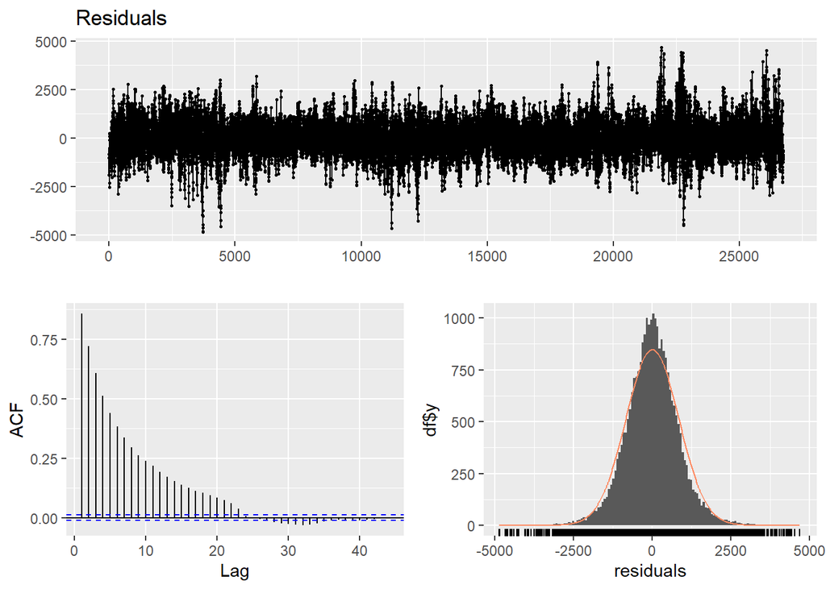

```r
checkresiduals(lm2_13$residuals)
```

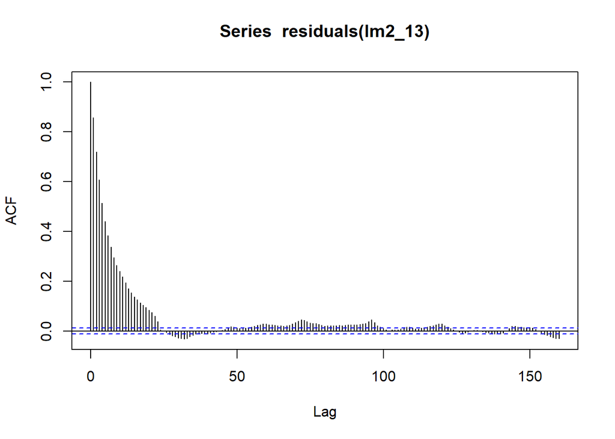

```r
tmp2[,residuals13 := residuals(lm2_13)]
acf(residuals(lm2_13) , lag.max = 160)
```

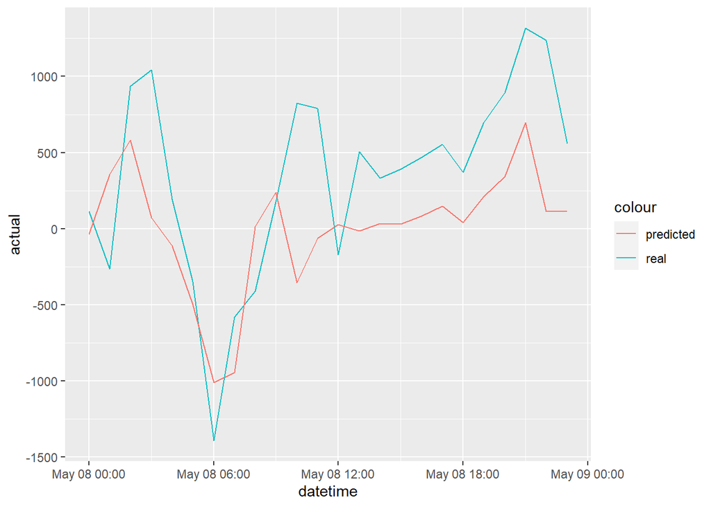

```r
ggplot(tmp2[Date=='2019-05-08'] ,aes(x=datetime)) +
        geom_line(aes(y=actual,color='real')) +
        geom_line(aes(y=predicted,color='predicted'))
```

### Submission

As mentioned before, we need to submit by estimating the system direction data, not the net bulk imbalance values. Therefore, we need to create system direction values from the imbalance values we estimated.

```r
tmp2 = tmp2 %>%
  mutate(predicted_diretion =
           case_when(predicted < -50 ~ "Negative" ,
                     predicted>=-50 & predicted<=50 ~ "Neutral" ,
                     predicted> 50 ~ "Positive" )
         )
tmp2= as.data.table(tmp2)
tmp2
```

[output not shown]

[output cut: 237 more lines]

```r
submission = tmp2[,list(Date,hour,system_direction,predicted_diretion)]
tail(submission,12)
```

```
##           Date hour system_direction predicted_diretion
##  1: 2022-01-18   12                            Positive
##  2: 2022-01-18   13                            Positive
##  3: 2022-01-18   14                            Positive
##  4: 2022-01-18   15                            Positive
##  5: 2022-01-18   16                            Positive
##  6: 2022-01-18   17                            Positive
##  7: 2022-01-18   18                            Positive
##  8: 2022-01-18   19                            Positive
##  9: 2022-01-18   20                            Positive
## 10: 2022-01-18   21                            Positive
## 11: 2022-01-18   22                            Positive
## 12: 2022-01-18   23                            Positive
```